# EP_Cereal

Project with three other members, Canberk Atak

2025-10-03

```r
getwd()
```

```
## [1] "C:/Users/muzaf/OneDrive/Masaüstü/Portfolio/Cereal_project/Estimating-Demand-for-Ready-to-Eat-Cereal-"
```

```r
knitr::opts_chunk$set(echo = TRUE)
```

# Libraries

```r
library(readxl)
library(data.table)
library(haven)
library(modelsummary)
```

```r
library(ggplot2)
library(tidyverse)
library(dplyr)
library(tidyr)
library(naniar)
library(fixest)
library(lfe)
library(sandwich)
library(lmtest)
library(knitr)
library(corrplot)
```

#Import data:

```r
datapath <- file.path(getwd(), "Cereal_Data.xls")
cerealdata <- read_excel(datapath)
```

# TASK 1

1. **Data Description.** **Provide a brief, non-technical, overview of the market using descriptive tools (tables, plots) and focusing on a lay audience. Which are the salient features of the market, the main brands, segments, and products?**

Missing observations:

```r
sapply(cerealdata, function(x) sum(is.na(x)))
```

```
##               0            Name Avg Trans Price Avg Shelf Price     Avg Ad Expn
##               0               0               0               1               0
##       Mkt Share           Sgmnt            Cals             Fat           Sugar
##               0               1               1               1               1
```

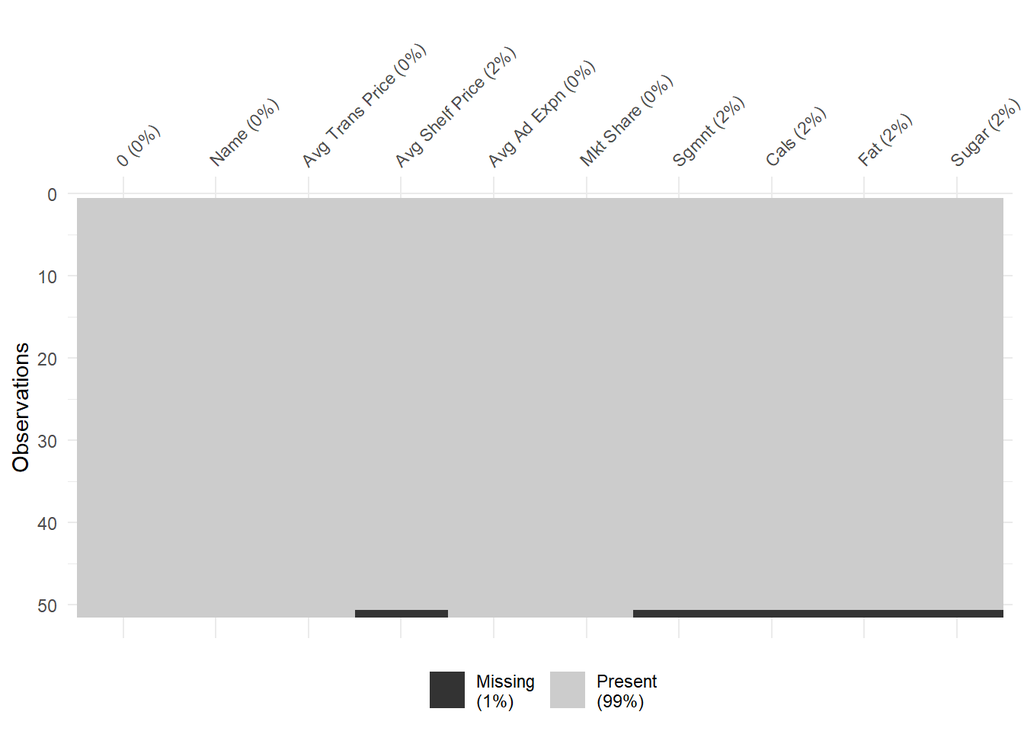

```r
library(naniar)
vis_miss(cerealdata, warn_large_data = FALSE)
```

In total 1% of observations are missing values.

## Remove rows with missing values

```r
cerealdata <- na.omit(cerealdata)
```

```r
datasummary( All(cerealdata) ~ mean + sd + min + median + max, fmt = 4, data = cerealdata, output = "markdown")
```

|  | mean | sd | min | median | max |
| --- | --- | --- | --- | --- | --- |
| 0 | 25.5000 | 14.5774 | 1.0000 | 25.5000 | 50.0000 |
| Avg Trans Price | 2.9830 | 0.4916 | 1.7700 | 3.0150 | 3.9600 |
| Avg Shelf Price | 3.2418 | 0.5262 | 1.7700 | 3.4000 | 4.2200 |
| Avg Ad Expn | 2.8643 | 1.9049 | 0.0000 | 2.5435 | 7.8670 |
| Mkt Share | 1.5154 | 1.0247 | 0.6700 | 1.1500 | 5.6700 |
| Cals | 145.6200 | 41.5397 | 100.0000 | 120.0000 | 220.0000 |
| Fat | 1.6080 | 1.6884 | 0.0000 | 1.0000 | 8.0000 |
| Sugar | 10.1080 | 5.4177 | 0.0000 | 11.2500 | 20.0000 |

##discount&coupons

```r
# create a variable "coupon"
cerealdata <- cerealdata%>%
  mutate(coupon = `Avg Shelf Price` - `Avg Trans Price`)
```

```r
# Group, breakfast cereals under the different market segment
avg_prices_by_segment <- cerealdata %>%
  group_by(Sgmnt) %>%
  summarise(AvgShelfPrice = mean(`Avg Shelf Price`, na.rm = TRUE))

print(avg_prices_by_segment)
```

```
## # A tibble: 3 × 2
##   Sgmnt AvgShelfPrice
##   <chr>         <dbl>
## 1 Adult          3.20
## 2 Fam            3.08
## 3 Kids           3.51
```

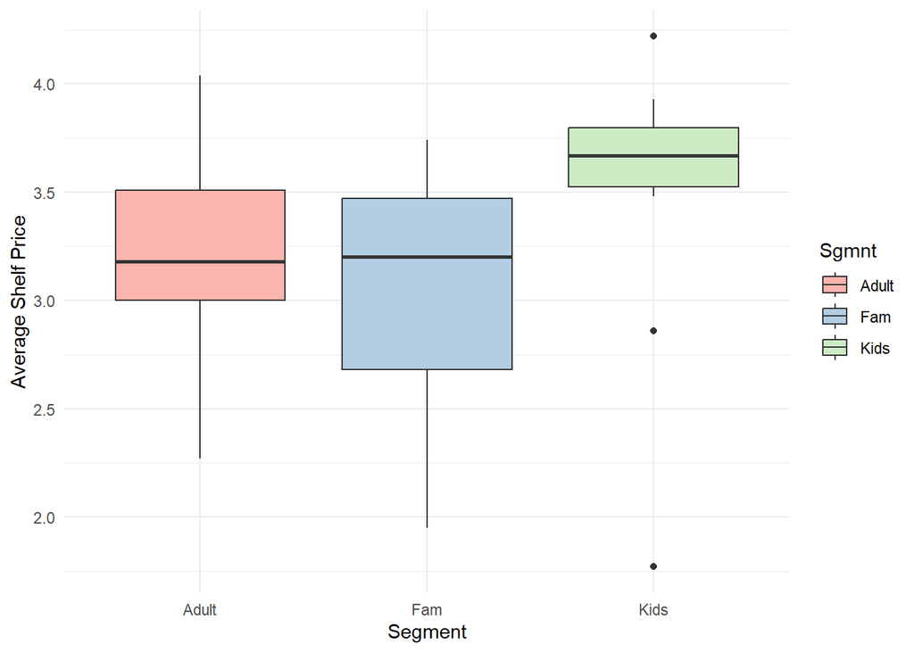

```r
# Different prices for consumer heterogeneity

plot_1 <- ggplot(cerealdata, aes(x = Sgmnt, y = `Avg Shelf Price`, fill = Sgmnt)) +
  geom_boxplot() +
  labs(x = "Segment",
       y = "Average Shelf Price") +
  theme_minimal() +
  scale_fill_brewer(palette = "Pastel1") +
  theme(plot.title = element_text(face = "italic"))

ggsave("Comparison of Average Shelf Prices by Segment.jpeg", plot = plot_1, width = 10, height = 6, dpi = 600)

print(plot_1)
```

```r
#
# # Top 10 cereals in the market based on their Market share
#
# plot_2 <- cerealdata %>%
#   top_n(10, `Mkt Share`) %>%
#   ggplot(aes(x = reorder(Name, `Mkt Share`), y = `Mkt Share`)) +
#   geom_bar(stat = "identity", fill = "darkblue") +
#   coord_flip() + # This makes it horizontal for better readability
#   labs(title = "Top 10 Cereals by Market Share", x = "", y = "Market Share (%)") +
#   theme_minimal()
#
# print(plot_2)
#
# ggsave(filename = "Top 10 Cereals by Market Share.jpeg" ,plot_2 )
```

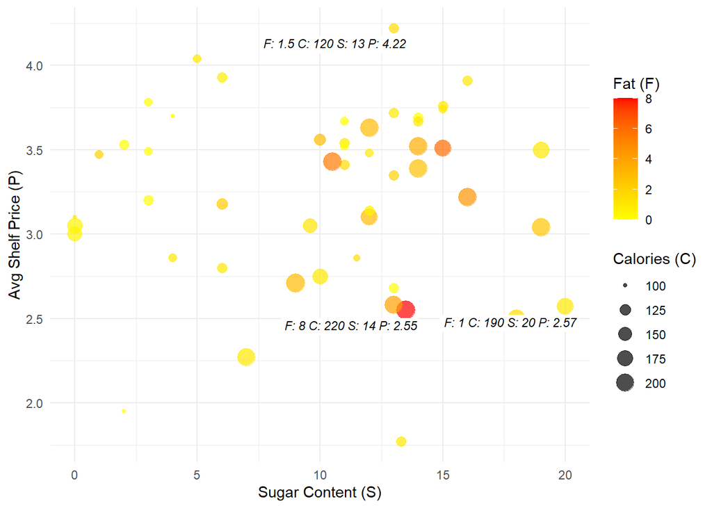

```r
# Seeing the different price and different nutritional values
# Identifying the row with the maximum value for each variable

max_fat <- cerealdata[which.max(cerealdata$Fat),]
max_cals <- cerealdata[which.max(cerealdata$Cals),]
max_sugar <- cerealdata[which.max(cerealdata$Sugar),]
max_price <- cerealdata[which.max(cerealdata$`Avg Shelf Price`),]

# Combining these into a single data frame for annotation
max_values <- bind_rows(max_fat, max_cals, max_sugar, max_price)

plot_3 <- ggplot(cerealdata, aes(x = Sugar, y = `Avg Shelf Price`, size = Cals, color = Fat)) +
  geom_point(alpha = 0.7) +
  geom_label(data = max_values,
             aes(label = paste("F:", round(Fat,1), "C:", round(Cals,0), "S:", round(Sugar,0), "P:", round(`Avg Shelf Price`,2))),
             hjust = 0.9, vjust = 1.5,
             size = 3,
             label.size = NA,
             lineheight = 0.9,
             fontface = "italic",
             color = "black") +
  scale_color_gradient(low = "yellow", high = "red") +
  labs(x = "Sugar Content (S)",
       y = "Avg Shelf Price (P)",
       color = "Fat Content",
       size = "Calorie Count") +
  theme_minimal() +
  guides(color = guide_colourbar(title = "Fat (F)"), size = guide_legend(title = "Calories (C)")) +
  theme(legend.position = "right")


ggsave(filename = "Average Shelf Price vs. Nutritional Values.jpeg", plot = plot_3, dpi = 900)
print(plot_3)
```

```r
# ggplot(cerealdata, aes(x = `Avg Ad Expn`, y = coupon)) +
#   geom_point(aes(color = Sgmnt), alpha = 0.7) +
#   geom_smooth(method = "lm", se = FALSE, color = "gray") +
#   labs(title = "Relationship Between Advertising Expenses and Discounts",
#        x = "Average Advertising Expenditure",
#        y = "Discount Amount") +
#   theme_minimal() +
#   scale_color_brewer(palette = "Pastel1")
```

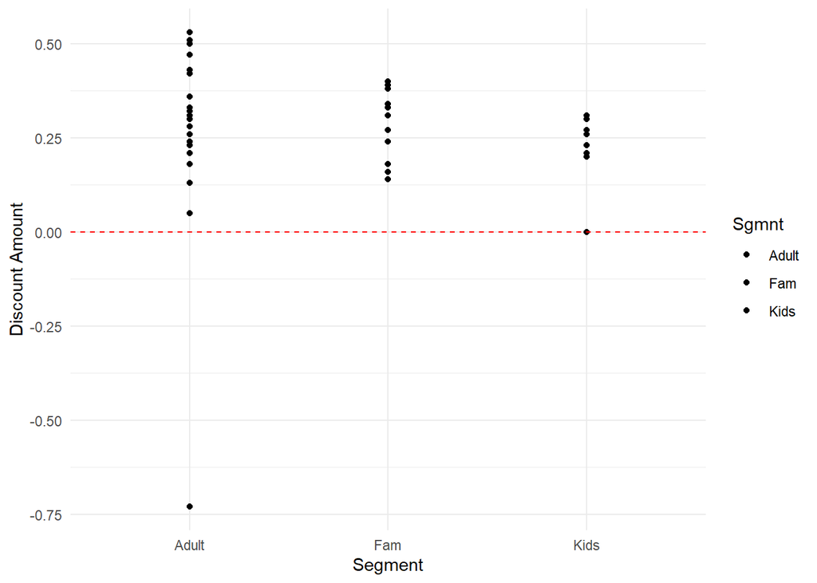

```r
# Different Discounts for different Segment

plot_4 <- ggplot(cerealdata, aes(x = Sgmnt, y = coupon, fill = Sgmnt)) +
  geom_point() +
  labs(x = "Segment",
       y = "Discount Amount") +
  theme_minimal() +
  scale_fill_brewer(palette = "Pastel1") +
  geom_hline(yintercept = 0, linetype = "dashed", color = "red", linewidth = 0.5) +
  theme(plot.title = element_text(face = "italic"))


ggsave(filename = "Discount Distribution by Segment.jpeg",plot = plot_4, dpi = 600)
print(plot_4)
```

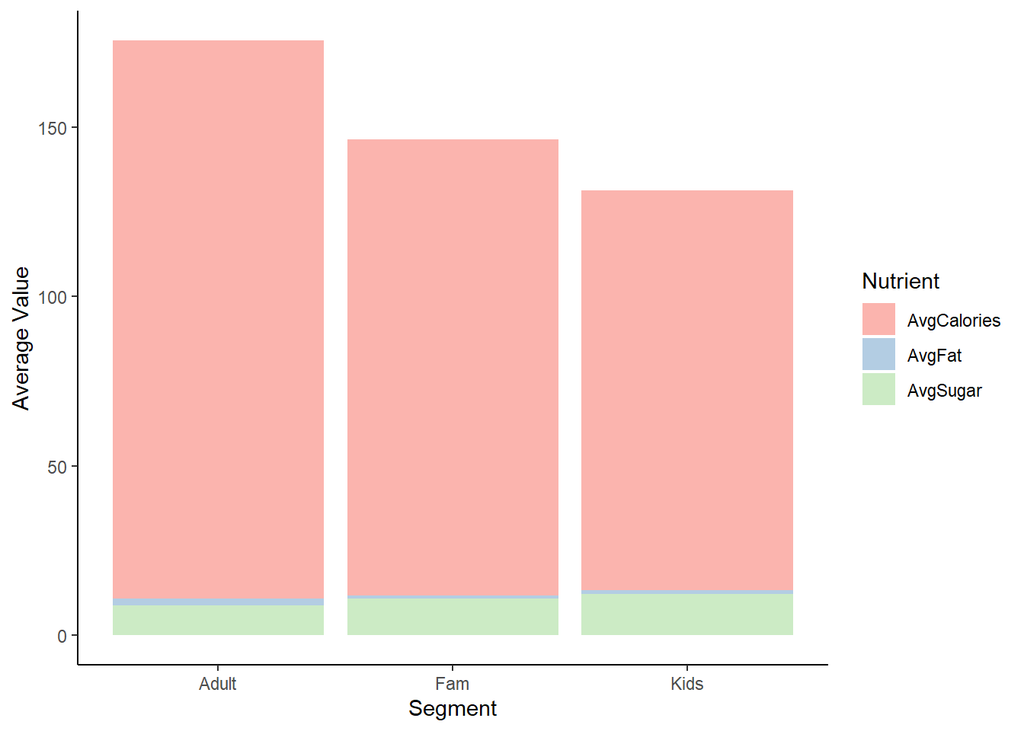

```r
#

plot_5 <- cerealdata %>%
  group_by(Sgmnt) %>%
  summarise(AvgCalories = mean(Cals, na.rm = TRUE),
            AvgFat = mean(Fat, na.rm = TRUE),
            AvgSugar = mean(Sugar, na.rm = TRUE)) %>%
  gather(key = "Nutrient", value = "Average", -Sgmnt) %>%
  ggplot(aes(x = Sgmnt, y = Average, fill = Nutrient)) +
  geom_bar(stat = "identity") +
  labs(x = "Segment", y = "Average Value") +
  theme_classic() +
  scale_fill_brewer(palette = "Pastel1")


ggsave(filename = "Average Nutritional Values by Segment.jpeg",plot = plot_5, dpi = 600)
print(plot_5)
```

```r
unique_product <- unique(cerealdata$Name)
unique_product
```

```
##  [1] "KG Corn Flakes"           "GM Cheerios"
##  [3] "KG Rice Krispies"         "KG Frosted Flakes"
##  [5] "KG Raisin Bran"           "GM Total"
##  [7] "GM HoneyNut Cheerios"     "KG Special K"
##  [9] "PT Grape Nuts"            "NB SpoonSize ShdWt"
## [11] "QK 100% Natural"          "KG Frosted Mini Wheats"
## [13] "KG NutriGrain"            "KG Muesliz"
## [15] "GM Wheaties"              "PT Raisin Bran"
## [17] "RL Muesli"                "KG Corn Pops"
## [19] "GM Raisin Nut Bran"       "GM Basic 4"
## [21] "GM Cocoa Puffs"           "GM Golden Grahams"
## [23] "GM Cinn. Toast Crunch"    "KG Froot Loops"
## [25] "KG Low Fat Granola"       "GM Trix"
## [27] "GM Triples"               "KG Crispix"
## [29] "GM Kix"                   "GM Lucky Charms"
## [31] "GM AppleCinn. Cheerios"   "KG Cracklin Oat Bran"
## [33] "NB Big Biscuit Shd Wt"    "PT Honey Bunches of Oats"
## [35] "PT Great Graines"         "GM Otml Raisin Crisp"
## [37] "QK Oat Sqyares"           "RL Rice Chex"
## [39] "GM Total Raisin Bran"     "KG Product 19"
## [41] "KG Apple Jacks"           "QK Capt Crunch"
## [43] "NB Shredded Wheat"        "PT Fuity Pebbles"
## [45] "GM Clusters"              "KG Cinnamon MiniBuns"
## [47] "KG Double Dip Crunch"     "GM MultiGrain Cheerios"
## [49] "PT Honeycomb"             "QK Popeye"
```

##brand

```r
cerealdata <- cerealdata %>%
  mutate(Brand = sub(" .*", "", Name))
```

```r
unique_brand <- unique(cerealdata$Brand)
unique_brand
```

```
## [1] "KG" "GM" "PT" "NB" "QK" "RL"
```

## Plots of market share grouped by brand

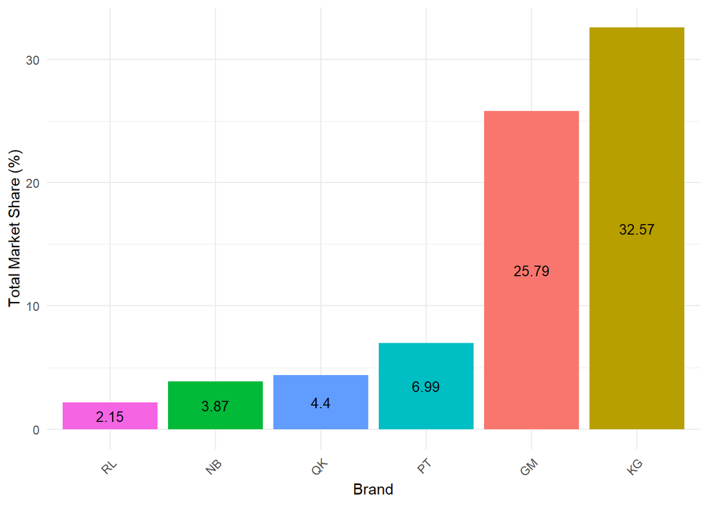

```r
# Calculating total market share for each brand
df_brand <- cerealdata %>%
  group_by(Brand) %>%
  summarize(total_market_share = sum(`Mkt Share`)) %>%
  arrange(desc(total_market_share))

# Plot
plot_6 <- ggplot(df_brand, aes(x = reorder(Brand, total_market_share), y = total_market_share, fill = Brand)) +
  geom_bar(stat = "identity") +
  geom_text(aes(label = total_market_share), position = position_stack(vjust = 0.5), size = 3.5, color = "black") +
  labs(x = "Brand",
       y = "Total Market Share (%)") +
  theme_minimal() +
  theme(axis.text.x = element_text(angle = 45, hjust = 1),
        legend.position = "none")

ggsave("Market Share by Brands.jpeg", plot_6)
print(plot_6)
```

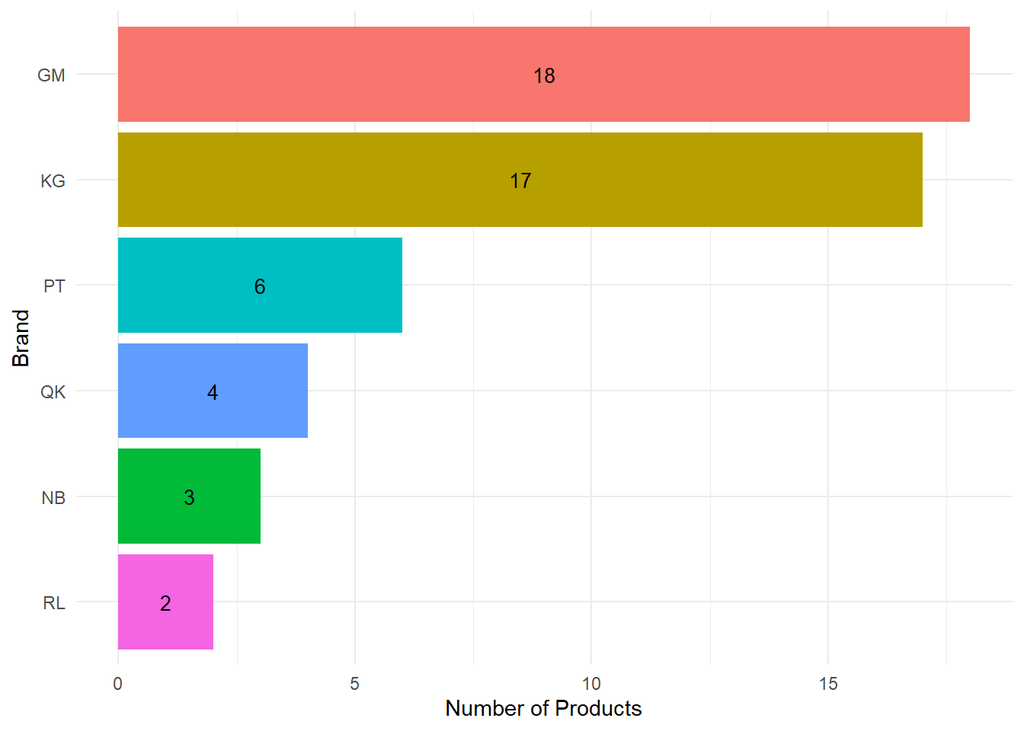

```r
# Counting the number of products for each brand
brand_counts <- cerealdata %>%
  group_by(Brand) %>%
  summarise(Products = n())

# Creating a bar plot showing the number of products for each brand
plot_7 <- ggplot(brand_counts, aes(x = reorder(Brand, Products), y = Products, fill = Brand)) +
  geom_bar(stat = "identity") +
  geom_text(aes(label = Products), position = position_stack(vjust = 0.5), size = 3.5, color = "black") +
  coord_flip() +
  labs(x = "Brand",
       y = "Number of Products") +
  theme_minimal() +
  theme(legend.position = "none")

ggsave("Number of Products by Brand.jpeg", plot_7)
print(plot_7)
```

```r
unique_product <- unique(cerealdata$Name)
unique_product
```

```
##  [1] "KG Corn Flakes"           "GM Cheerios"
##  [3] "KG Rice Krispies"         "KG Frosted Flakes"
##  [5] "KG Raisin Bran"           "GM Total"
##  [7] "GM HoneyNut Cheerios"     "KG Special K"
##  [9] "PT Grape Nuts"            "NB SpoonSize ShdWt"
## [11] "QK 100% Natural"          "KG Frosted Mini Wheats"
## [13] "KG NutriGrain"            "KG Muesliz"
## [15] "GM Wheaties"              "PT Raisin Bran"
## [17] "RL Muesli"                "KG Corn Pops"
## [19] "GM Raisin Nut Bran"       "GM Basic 4"
## [21] "GM Cocoa Puffs"           "GM Golden Grahams"
## [23] "GM Cinn. Toast Crunch"    "KG Froot Loops"
## [25] "KG Low Fat Granola"       "GM Trix"
## [27] "GM Triples"               "KG Crispix"
## [29] "GM Kix"                   "GM Lucky Charms"
## [31] "GM AppleCinn. Cheerios"   "KG Cracklin Oat Bran"
## [33] "NB Big Biscuit Shd Wt"    "PT Honey Bunches of Oats"
## [35] "PT Great Graines"         "GM Otml Raisin Crisp"
## [37] "QK Oat Sqyares"           "RL Rice Chex"
## [39] "GM Total Raisin Bran"     "KG Product 19"
## [41] "KG Apple Jacks"           "QK Capt Crunch"
## [43] "NB Shredded Wheat"        "PT Fuity Pebbles"
## [45] "GM Clusters"              "KG Cinnamon MiniBuns"
## [47] "KG Double Dip Crunch"     "GM MultiGrain Cheerios"
## [49] "PT Honeycomb"             "QK Popeye"
```

## Plots of market share grouped by brand

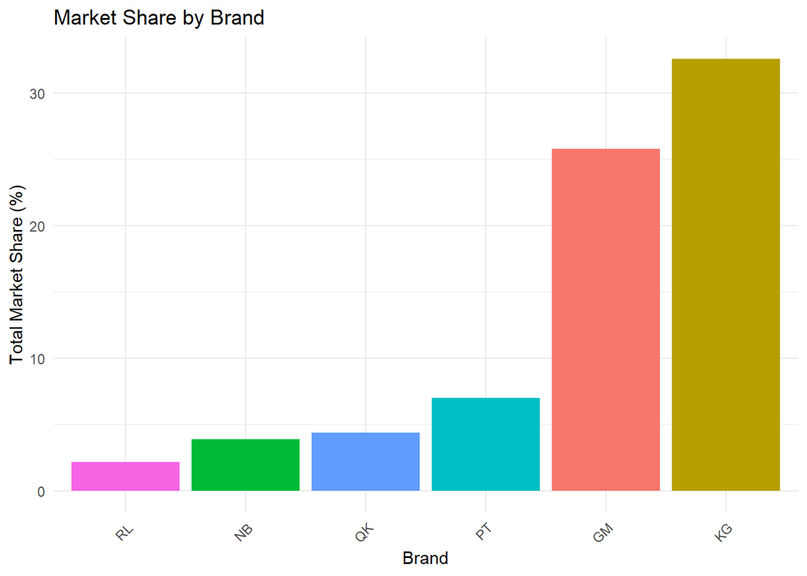

```r
library(ggplot2)

# Calculate total market share for each brand
df_brand <- cerealdata %>%
  group_by(Brand) %>%
  summarize(total_market_share = sum(`Mkt Share`)) %>%
  arrange(desc(total_market_share))

# Plot
ggplot(df_brand, aes(x = reorder(Brand, total_market_share), y = total_market_share, fill = Brand)) +
  geom_bar(stat = "identity") +
  labs(title = "Market Share by Brand",
       x = "Brand",
       y = "Total Market Share (%)") +
  theme_minimal() +
  theme(axis.text.x = element_text(angle = 45, hjust = 1),
        legend.position = "none")
```

# TASK 2

2. **The basics and OLS estimation.** **Load the data, define the share of the outside good, create a variable to store the brand information and create the dependent variable to be used in the logit regressions (mean utility). Then estimate the following six specifications using OLS and including product characteristics Price, Cals, Fat, and Sugar:**

Load data:

```r
datapath <- file.path(getwd(), "Cereal_Data.xls")
cerealdata <- read_excel(datapath)
cerealdata <- na.omit(cerealdata)
names(cerealdata)
```

```
##  [1] "0"               "Name"            "Avg Trans Price" "Avg Shelf Price"
##  [5] "Avg Ad Expn"     "Mkt Share"       "Sgmnt"           "Cals"
##  [9] "Fat"             "Sugar"
```

*share of the outside good*

```r
outside_share=100-round(sum(cerealdata$`Mkt Share`))
```

*brand information*

```r
cerealdata <- cerealdata %>%
  mutate(
    Brand = word(Name, 1, sep = " "),
    Product = word(Name, 2, sep = " "))
cerealdata$fbrand <- as.factor(cerealdata$Brand)
cerealdata$fsegment <- as.factor(cerealdata$Sgmnt)
```

```r
names(cerealdata)
```

```
##  [1] "0"               "Name"            "Avg Trans Price" "Avg Shelf Price"
##  [5] "Avg Ad Expn"     "Mkt Share"       "Sgmnt"           "Cals"
##  [9] "Fat"             "Sugar"           "Brand"           "Product"
## [13] "fbrand"          "fsegment"
```

```r
cerealdata <- cerealdata %>%
  mutate(dummy = model.matrix(~ fbrand - 1, data = .))
```

*mean utility as dependent variable*

```r
cerealdata <- cerealdata %>%
  mutate(mean_utility = log(`Mkt Share`) - log(outside_share))
```

**Then estimate the following six specifications using OLS and including product characteristics Price, Cals, Fat, and Sugar:**

```r
names(cerealdata)
```

```
##  [1] "0"               "Name"            "Avg Trans Price" "Avg Shelf Price"
##  [5] "Avg Ad Expn"     "Mkt Share"       "Sgmnt"           "Cals"
##  [9] "Fat"             "Sugar"           "Brand"           "Product"
## [13] "fbrand"          "fsegment"        "dummy"           "mean_utility"
```

*(1) Without brand fixed-effects, standard errors assuming IID errors;*

```r
# Model specification without brand fixed-effects and with IID standard errors
ols_1 <- feols(mean_utility ~Cals + Fat + Sugar+`Avg Shelf Price`, data = cerealdata, se = 'iid')
summary(ols_1)
```

```
## OLS estimation, Dep. Var.: mean_utility
## Observations: 50
## Standard-errors: IID
##                    Estimate Std. Error   t value  Pr(>|t|)
## (Intercept)       -1.761605   0.609939 -2.888166 0.0059381 **
## Cals               0.000043   0.002495  0.017160 0.9863846
## Fat               -0.000561   0.056523 -0.009931 0.9921202
## Sugar             -0.028234   0.014011 -2.015177 0.0498831 *
## `Avg Shelf Price` -0.267781   0.138457 -1.934033 0.0594128 .
## ---
## Signif. codes:  0 '***' 0.001 '**' 0.01 '*' 0.05 '.' 0.1 ' ' 1
## RMSE: 0.451604   Adj. R2: 0.102238
```

*(2) Without brand fixed-effects, heteroskedasticity-robust standard errors;*

```r
ols_2 <- feols(mean_utility ~ Cals + Fat + Sugar+`Avg Shelf Price`, data = cerealdata, vcov = "HC1")
summary(ols_2)
```

```
## OLS estimation, Dep. Var.: mean_utility
## Observations: 50
## Standard-errors: Heteroskedasticity-robust
##                    Estimate Std. Error   t value Pr(>|t|)
## (Intercept)       -1.761605   0.905637 -1.945156  0.05802 .
## Cals               0.000043   0.002643  0.016200  0.98715
## Fat               -0.000561   0.048321 -0.011617  0.99078
## Sugar             -0.028234   0.016836 -1.677011  0.10047
## `Avg Shelf Price` -0.267781   0.206625 -1.295980  0.20159
## ---
## Signif. codes:  0 '***' 0.001 '**' 0.01 '*' 0.05 '.' 0.1 ' ' 1
## RMSE: 0.451604   Adj. R2: 0.102238
```

*(3) Without brand fixed-effects, standard errors clustered at the brand level*

```r
ols_3 <- feols(mean_utility ~ Cals + Fat + Sugar+`Avg Shelf Price` , data = cerealdata, se = 'cluster', cluster = "Brand")
summary(ols_3)
```

```
## OLS estimation, Dep. Var.: mean_utility
## Observations: 50
## Standard-errors: Clustered (Brand)
##                    Estimate Std. Error   t value Pr(>|t|)
## (Intercept)       -1.761605   1.045928 -1.684250  0.15295
## Cals               0.000043   0.002113  0.020269  0.98461
## Fat               -0.000561   0.061800 -0.009083  0.99310
## Sugar             -0.028234   0.014568 -1.938138  0.11033
## `Avg Shelf Price` -0.267781   0.287231 -0.932284  0.39398
## ---
## Signif. codes:  0 '***' 0.001 '**' 0.01 '*' 0.05 '.' 0.1 ' ' 1
## RMSE: 0.451604   Adj. R2: 0.102238
```

*By adding a brand fixed-effect I control for unobserved quality,* *(4) With brand fixed-effects, standard errors assuming IID errors;*

```r
ols_4 <- feols(mean_utility ~ Cals + Fat + Sugar+`Avg Shelf Price`| fbrand, data = cerealdata,
                     se = 'iid')
summary(ols_4)
```

```
## OLS estimation, Dep. Var.: mean_utility
## Observations: 50
## Fixed-effects: fbrand: 6
## Standard-errors: IID
##                    Estimate Std. Error   t value  Pr(>|t|)
## Cals               0.001039   0.002683  0.387330 0.7005651
## Fat                0.015549   0.059908  0.259545 0.7965463
## Sugar             -0.037275   0.014459 -2.577907 0.0137295 *
## `Avg Shelf Price` -0.443217   0.154931 -2.860740 0.0066887 **
## ---
## Signif. codes:  0 '***' 0.001 '**' 0.01 '*' 0.05 '.' 0.1 ' ' 1
## RMSE: 0.391354     Adj. R2: 0.241534
##                  Within R2: 0.314077
```

*(5) With brand fixed-effects, heteroskedasticity-robust standard errors*

```r
ols_5 <- feols(mean_utility ~ Cals + Fat + Sugar+`Avg Shelf Price`| fbrand, data = cerealdata,
                     vcov = 'HC1')
summary(ols_5)
```

```
## OLS estimation, Dep. Var.: mean_utility
## Observations: 50
## Fixed-effects: fbrand: 6
## Standard-errors: Heteroskedasticity-robust
##                    Estimate Std. Error   t value Pr(>|t|)
## Cals               0.001039   0.002102  0.494363 0.623754
## Fat                0.015549   0.054568  0.284942 0.777159
## Sugar             -0.037275   0.015634 -2.384172 0.021950 *
## `Avg Shelf Price` -0.443217   0.173060 -2.561059 0.014313 *
## ---
## Signif. codes:  0 '***' 0.001 '**' 0.01 '*' 0.05 '.' 0.1 ' ' 1
## RMSE: 0.391354     Adj. R2: 0.241534
##                  Within R2: 0.314077
```

*(6) With brand fixed-effects, standard errors clustered at the brand level*

```r
ols_6 <- feols(mean_utility ~ Cals + Fat + Sugar+`Avg Shelf Price` | fbrand,  data = cerealdata)
summary(ols_6)
```

```
## OLS estimation, Dep. Var.: mean_utility
## Observations: 50
## Fixed-effects: fbrand: 6
## Standard-errors: Clustered (fbrand)
##                    Estimate Std. Error   t value Pr(>|t|)
## Cals               0.001039   0.001253  0.829313 0.444702
## Fat                0.015549   0.072256  0.215190 0.838122
## Sugar             -0.037275   0.010880 -3.426029 0.018716 *
## `Avg Shelf Price` -0.443217   0.196848 -2.251563 0.074131 .
## ---
## Signif. codes:  0 '***' 0.001 '**' 0.01 '*' 0.05 '.' 0.1 ' ' 1
## RMSE: 0.391354     Adj. R2: 0.241534
##                  Within R2: 0.314077
```

#table with results#

```r
coef <- list('Intercept'="Intercept",
              'Cals' = 'Caloric content of the product, per portion',
             'Fat' = 'Fat content of the product, per portion',
             'Sugar' = 'Sugar content of the product, per portion',
             'Avg Shelf Price' = 'Average shelf price')

gof <- data.frame(raw = c("nobs", "adj.r.squared"),
                  clean = c("Observations", "R2 adj."),
                  fmt = c(0,3))

fe <- data.frame(FE = c("Brand FE","errors"),
                 mod1 = c("No","idd"),
                 mod2 = c("No","HC1"),
                 mod3 = c("No","clustered"),
                 mod4 = c("Yes","idd"),
                 mod5 = c("Yes","HC1"),
                 mod6 = c("Yes","clustered"))
attr(fe, "position") <- c(11,12)

modelsummary(list(ols_1, ols_2, ols_3, ols_4, ols_5,ols_6),
              stars = c("*" = .1, "**" = .05, "***" = .01),
              title = "Table 1: Analysis of cereal market using OLS with and without brand fixed-effects",gof_map = gof, add_rows = fe, output = "markdown")
```

|  | (1) | (2) | (3) | (4) | (5) | (6) |
| --- | --- | --- | --- | --- | --- | --- |
| (Intercept) | -1.762*** | -1.762* | -1.762 |  |  |  |
|  | (0.610) | (0.906) | (1.046) |  |  |  |
| Cals | 0.000 | 0.000 | 0.000 | 0.001 | 0.001 | 0.001 |
|  | (0.002) | (0.003) | (0.002) | (0.003) | (0.002) | (0.001) |
| Fat | -0.001 | -0.001 | -0.001 | 0.016 | 0.016 | 0.016 |
|  | (0.057) | (0.048) | (0.062) | (0.060) | (0.055) | (0.072) |
| Sugar | -0.028** | -0.028 | -0.028 | -0.037** | -0.037** | -0.037** |
|  | (0.014) | (0.017) | (0.015) | (0.014) | (0.016) | (0.011) |
| Avg Shelf Price | -0.268* | -0.268 | -0.268 | -0.443*** | -0.443** | -0.443* |
|  | (0.138) | (0.207) | (0.287) | (0.155) | (0.173) | (0.197) |
| Brand FE | No | No | No | Yes | Yes | Yes |
| errors | idd | HC1 | clustered | idd | HC1 | clustered |
| Observations | 50 | 50 | 50 | 50 | 50 | 50 |
| R2 adj. | 0.102 | 0.102 | 0.102 | 0.242 | 0.242 | 0.242 |

* p < 0.1, ** p < 0.05, *** p < 0.01

```r
cerealdata <- cerealdata %>%
  mutate(discount_coupon = `Avg Shelf Price` - `Avg Trans Price`)
```

# TASK 3

3. **Instruments and IV estimation. Construct instruments to account for price endogeneity and use them to perform IV estimation. Report estimates on a table with specifications differing according to the instruments used. Which instruments have you constructed, and why? Can one claim that the more the merrier when it comes to instruments in this case? Note. Use the OLS estimates without and with brand fixed-effects with your preferred standard errors. Instrument each of them with the instruments you constructed and report a table with 6-8 specifications in total**.

```r
library(ggplot2)
library(corrplot)
library(openxlsx)
cerealdata <- cerealdata %>%
  mutate(fsgmnt = as.factor(Sgmnt))
cor_matrix <- cor(subset(cerealdata, select = c("Avg Shelf Price", "Avg Trans Price" ,"Avg Ad Expn")))
print(cor_matrix)
```

```
##                 Avg Shelf Price Avg Trans Price Avg Ad Expn
## Avg Shelf Price       1.0000000       0.9393441  -0.1827008
## Avg Trans Price       0.9393441       1.0000000  -0.1768049
## Avg Ad Expn          -0.1827008      -0.1768049   1.0000000
```

```r
correlation_matrix <- cor(cerealdata[, c("Avg Shelf Price","Avg Trans Price","Avg Ad Expn")])

png("heatmap_base.png", width = 800, height = 1200, res = 300)
heatmap(correlation_matrix)
dev.off()
```

```r
png("heatmap_corrplot.png", width = 800, height =1080, res =150)
corrplot(correlation_matrix, method = "color",
         type = "upper",
         order = "hclust",
         addCoef.col = "black",
         col = colorRampPalette(c("lightblue", "darkblue"))(200),
         title = "Correlation Matrix",
         tl.col = "black", tl.srt = 30)
dev.off()
```

```r
#  OLS with fixed effects
summary(ols1_1 <- feols(mean_utility ~ Cals + Fat + Sugar + `Avg Shelf Price`, data = cerealdata, se = 'iid'))
```

```
## OLS estimation, Dep. Var.: mean_utility
## Observations: 50
## Standard-errors: IID
##                    Estimate Std. Error   t value  Pr(>|t|)
## (Intercept)       -1.761605   0.609939 -2.888166 0.0059381 **
## Cals               0.000043   0.002495  0.017160 0.9863846
## Fat               -0.000561   0.056523 -0.009931 0.9921202
## Sugar             -0.028234   0.014011 -2.015177 0.0498831 *
## `Avg Shelf Price` -0.267781   0.138457 -1.934033 0.0594128 .
## ---
## Signif. codes:  0 '***' 0.001 '**' 0.01 '*' 0.05 '.' 0.1 ' ' 1
## RMSE: 0.451604   Adj. R2: 0.102238
```

```r
#IV with average advertising expenditure * brand
summary(iv1a_2 <- feols(mean_utility ~ Cals + Fat + Sugar | `Avg Shelf Price` ~ `Avg Ad Expn`:fbrand, data = cerealdata, se = 'iid'))
```

```
## TSLS estimation - Dep. Var.: mean_utility
##                   Endo.    : `Avg Shelf Price`
##                   Instr.   : `Avg Ad Expn`:fbrand
## Second stage: Dep. Var.: mean_utility
## Observations: 50
## Standard-errors: IID
##                        Estimate Std. Error   t value Pr(>|t|)
## (Intercept)           -0.478423   1.173293 -0.407761 0.685383
## fit_`Avg Shelf Price` -0.597983   0.291552 -2.051032 0.046113 *
## Cals                  -0.001983   0.003066 -0.646822 0.521033
## Fat                    0.017643   0.061574  0.286537 0.775782
## Sugar                 -0.022990   0.015398 -1.493041 0.142405
## ---
## Signif. codes:  0 '***' 0.001 '**' 0.01 '*' 0.05 '.' 0.1 ' ' 1
## RMSE: 0.479295   Adj. R2: -0.01123
## F-test (1st stage), `Avg Shelf Price`: stat =  2.27027, p = 0.055895, on 6 and 40 DoF.
##                            Wu-Hausman: stat =  1.97898, p = 0.166522, on 1 and 44 DoF.
##                                Sargan: stat = 29.9    , p = 1.567e-5, on 5 DoF.
```

```r
# IV with average average transaction price * brand
summary(iv1a_3 <- feols(mean_utility ~ Cals + Fat + Sugar  | `Avg Shelf Price` ~ `Avg Trans Price`:fbrand, data = cerealdata, se = 'iid'))
```

```
## TSLS estimation - Dep. Var.: mean_utility
##                   Endo.    : `Avg Shelf Price`
##                   Instr.   : `Avg Trans Price`:fbrand
## Second stage: Dep. Var.: mean_utility
## Observations: 50
## Standard-errors: IID
##                        Estimate Std. Error   t value  Pr(>|t|)
## (Intercept)           -1.924107   0.641137 -3.001085 0.0043766 **
## fit_`Avg Shelf Price` -0.225965   0.147458 -1.532395 0.1324258
## Cals                   0.000299   0.002517  0.118955 0.9058403
## Fat                   -0.002867   0.056648 -0.050606 0.9598632
## Sugar                 -0.028898   0.014048 -2.057149 0.0454953 *
## ---
## Signif. codes:  0 '***' 0.001 '**' 0.01 '*' 0.05 '.' 0.1 ' ' 1
## RMSE: 0.452062   Adj. R2: 0.100418
## F-test (1st stage), `Avg Shelf Price`: stat = 50.5     , p < 2.2e-16 , on 6 and 40 DoF.
##                            Wu-Hausman: stat =  0.686471, p = 0.411839, on 1 and 44 DoF.
##                                Sargan: stat = 11.4     , p = 0.044186, on 5 DoF.
```

```r
#  IV with average average transaction price * brand + advertising expenditure * brand
summary(iv1a_4 <- feols(mean_utility ~ Cals + Fat + Sugar | `Avg Shelf Price` ~ `Avg Trans Price`:fbrand + `Avg Ad Expn`:fbrand, data = cerealdata, se = 'iid'))
```

```
## TSLS estimation - Dep. Var.: mean_utility
##                   Endo.    : `Avg Shelf Price`
##                   Instr.   : `Avg Trans Price`:fbrand, fbrand:`Avg Ad Expn`
## Second stage: Dep. Var.: mean_utility
## Observations: 50
## Standard-errors: IID
##                        Estimate Std. Error   t value Pr(>|t|)
## (Intercept)           -1.808195   0.635155 -2.846857 0.006629 **
## fit_`Avg Shelf Price` -0.255792   0.145769 -1.754778 0.086104 .
## Cals                   0.000116   0.002511  0.046347 0.963239
## Fat                   -0.001222   0.056583 -0.021602 0.982861
## Sugar                 -0.028425   0.014031 -2.025900 0.048729 *
## ---
## Signif. codes:  0 '***' 0.001 '**' 0.01 '*' 0.05 '.' 0.1 ' ' 1
## RMSE: 0.451642   Adj. R2: 0.102088
## F-test (1st stage), `Avg Shelf Price`: stat = 26.2     , p = 1.084e-13, on 12 and 34 DoF.
##                            Wu-Hausman: stat =  0.067851, p = 0.795707 , on 1 and 44 DoF.
##                                Sargan: stat = 39.6     , p = 4.197e-5 , on 11 DoF.
```

```r
#  benchmark: OLS with fixed effects
summary(ols_4_1 <- feols(mean_utility ~ Cals + Fat + Sugar + `Avg Shelf Price` | fbrand, data = cerealdata,
                     se = 'iid'))
```

```
## OLS estimation, Dep. Var.: mean_utility
## Observations: 50
## Fixed-effects: fbrand: 6
## Standard-errors: IID
##                    Estimate Std. Error   t value  Pr(>|t|)
## Cals               0.001039   0.002683  0.387330 0.7005651
## Fat                0.015549   0.059908  0.259545 0.7965463
## Sugar             -0.037275   0.014459 -2.577907 0.0137295 *
## `Avg Shelf Price` -0.443217   0.154931 -2.860740 0.0066887 **
## ---
## Signif. codes:  0 '***' 0.001 '**' 0.01 '*' 0.05 '.' 0.1 ' ' 1
## RMSE: 0.391354     Adj. R2: 0.241534
##                  Within R2: 0.314077
```

```r
#IV with average advertising expenditure * brand
summary(iv2a_5 <- feols(mean_utility ~ Cals + Fat + Sugar | fbrand | `Avg Shelf Price` ~ `Avg Ad Expn`:fbrand,
                        data = cerealdata, se = 'iid'))
```

```
## TSLS estimation - Dep. Var.: mean_utility
##                   Endo.    : `Avg Shelf Price`
##                   Instr.   : `Avg Ad Expn`:fbrand
## Second stage: Dep. Var.: mean_utility
## Observations: 50
## Fixed-effects: fbrand: 6
## Standard-errors: IID
##                        Estimate Std. Error   t value Pr(>|t|)
## fit_`Avg Shelf Price` -0.898467   0.285491 -3.147097 0.003111 **
## Cals                  -0.002118   0.003356 -0.630992 0.531635
## Fat                    0.063925   0.070388  0.908181 0.369222
## Sugar                 -0.029515   0.016414 -1.798221 0.079692 .
## ---
## Signif. codes:  0 '***' 0.001 '**' 0.01 '*' 0.05 '.' 0.1 ' ' 1
## RMSE: 0.431529     Adj. R2: 0.077814
##                  Within R2: 0.166016
## F-test (1st stage), `Avg Shelf Price`: stat =  3.25392, p = 0.01198 , on 6 and 35 DoF.
##                            Wu-Hausman: stat =  5.33872, p = 0.026234, on 1 and 39 DoF.
##                                Sargan: stat = 24.4    , p = 1.82e-4 , on 5 DoF.
```

```r
#  IV with  average transaction price * brand
summary(iv2a_6 <- feols(mean_utility ~ Cals + Fat + Sugar | fbrand | `Avg Shelf Price` ~ `Avg Trans Price`:fbrand,
                        data = cerealdata, se = 'iid'))
```

```
## TSLS estimation - Dep. Var.: mean_utility
##                   Endo.    : `Avg Shelf Price`
##                   Instr.   : `Avg Trans Price`:fbrand
## Second stage: Dep. Var.: mean_utility
## Observations: 50
## Fixed-effects: fbrand: 6
## Standard-errors: IID
##                        Estimate Std. Error   t value Pr(>|t|)
## fit_`Avg Shelf Price` -0.409198   0.169093 -2.419955 0.020159 *
## Cals                   0.001275   0.002725  0.467916 0.642384
## Fat                    0.011934   0.060372  0.197672 0.844303
## Sugar                 -0.037855   0.014514 -2.608192 0.012736 *
## ---
## Signif. codes:  0 '***' 0.001 '**' 0.01 '*' 0.05 '.' 0.1 ' ' 1
## RMSE: 0.391589     Adj. R2: 0.24062
##                  Within R2: 0.31325
## F-test (1st stage), `Avg Shelf Price`: stat = 30.7     , p = 1.451e-12, on 6 and 35 DoF.
##                            Wu-Hausman: stat =  0.249329, p = 0.620353 , on 1 and 39 DoF.
##                                Sargan: stat =  9.92037 , p = 0.077523 , on 5 DoF.
```

```r
#  IV with both  average transaction price * brand and advertising expenditure * brand
summary(iv2a_7 <- feols(mean_utility ~ Cals + Fat + Sugar | fbrand |
                               `Avg Shelf Price` ~ `Avg Ad Expn`:fbrand + `Avg Trans Price`:fbrand,
                             data = cerealdata, se = 'iid'))
```

```
## The instrument 'fbrandRL:`Avg Trans Price`' has been removed because of collinearity (see $collin.var).
```

```
## TSLS estimation - Dep. Var.: mean_utility
##                   Endo.    : `Avg Shelf Price`
##                   Instr.   : `Avg Ad Expn`:fbrand, fbrand:`Avg Trans Price`
## Second stage: Dep. Var.: mean_utility
## Observations: 50
## Fixed-effects: fbrand: 6
## Standard-errors: IID
##                        Estimate Std. Error   t value Pr(>|t|)
## fit_`Avg Shelf Price` -0.445565   0.167196 -2.664918 0.011051 *
## Cals                   0.001023   0.002718  0.376324 0.708665
## Fat                    0.015798   0.060279  0.262085 0.794601
## Sugar                 -0.037235   0.014499 -2.568092 0.014067 *
## ... 1 variable was removed because of collinearity (fbrandRL:`Avg Trans Price`)
## ---
## Signif. codes:  0 '***' 0.001 '**' 0.01 '*' 0.05 '.' 0.1 ' ' 1
## RMSE: 0.391355     Adj. R2: 0.241529
##                  Within R2: 0.314073
## F-test (1st stage), `Avg Shelf Price`: stat = 16.6     , p = 7.478e-10, on 11 and 30 DoF.
##                            Wu-Hausman: stat =  0.001361, p = 0.970765 , on 1 and 39 DoF.
##                                Sargan: stat = 39.5     , p = 4.323e-5 , on 11 DoF.
```

```r
# Define coefficients
coef <- list('Intercept'="Intercept",
             'Cals' = 'Caloric content of the product, per portion',
             'Fat' = 'Fat content of the product, per portion',
             'Sugar' = 'Sugar content of the product, per portion',
             'Avg Shelf Price' = 'Average shelf price')

# Define goodness-of-fit dataframe
gof <-  data.frame(raw = c("nobs", "adj.r.squared"),
                   clean = c("Observations", "R2 adj."),
                   fmt = c(0,3))

# Define fixed effects dataframe
fe <- data.frame(FE = c("Brand FE","Instruments"),
                 mod1 = c("No","None"),
                 mod2 = c("No", "Av. Adv Exp x Brand"),
                 mod3 = c("No","Avg Trans Price x Brand"),
                 mod4 = c("No","Avg Trans Price + Avg Trans Price x Brand"),
                 mod5 = c("Yes","None"),
                 mod6 = c("Yes","Av. Adv Exp x Brand"),
                 mod7 = c("Yes","Sugar x Brand"),
                 mod8 = c("Yes", "Avg Trans Price  + Avg Trans Price x Brand"))

attr(fe, "position") <- c(14,15)

# Generate model summary in markdown format
modelsummary(list(ols1_1, iv1a_2, iv1a_3, iv1a_4, ols_4_1, iv2a_5, iv2a_6,iv2a_7),
             stars = c("*" = .1, "**" = .05, "***" = .01),
             output = "markdown")
```

|  | (1) | (2) | (3) | (4) | (5) | (6) | (7) | (8) |
| --- | --- | --- | --- | --- | --- | --- | --- | --- |
| (Intercept) | -1.762*** | -0.478 | -1.924*** | -1.808*** |  |  |  |  |
|  | (0.610) | (1.173) | (0.641) | (0.635) |  |  |  |  |
| Cals | 0.000 | -0.002 | 0.000 | 0.000 | 0.001 | -0.002 | 0.001 | 0.001 |
|  | (0.002) | (0.003) | (0.003) | (0.003) | (0.003) | (0.003) | (0.003) | (0.003) |
| Fat | -0.001 | 0.018 | -0.003 | -0.001 | 0.016 | 0.064 | 0.012 | 0.016 |
|  | (0.057) | (0.062) | (0.057) | (0.057) | (0.060) | (0.070) | (0.060) | (0.060) |
| Sugar | -0.028** | -0.023 | -0.029** | -0.028** | -0.037** | -0.030* | -0.038** | -0.037** |
|  | (0.014) | (0.015) | (0.014) | (0.014) | (0.014) | (0.016) | (0.015) | (0.014) |
| Avg Shelf Price | -0.268* |  |  |  | -0.443*** |  |  |  |
|  | (0.138) |  |  |  | (0.155) |  |  |  |
| fit_Avg Shelf Price |  | -0.598** | -0.226 | -0.256* |  | -0.898*** | -0.409** | -0.446** |
|  |  | (0.292) | (0.147) | (0.146) |  | (0.285) | (0.169) | (0.167) |
| Num.Obs. | 50 | 50 | 50 | 50 | 50 | 50 | 50 | 50 |
| R2 | 0.176 | 0.071 | 0.174 | 0.175 | 0.381 | 0.247 | 0.380 | 0.381 |
| R2 Adj. | 0.102 | -0.011 | 0.100 | 0.102 | 0.242 | 0.078 | 0.241 | 0.242 |
| R2 Within |  |  |  |  | 0.314 | 0.166 | 0.313 | 0.314 |
| R2 Within Adj. |  |  |  |  | 0.245 | 0.083 | 0.245 | 0.245 |
| AIC | 72.4 | 78.3 | 72.5 | 72.4 | 68.1 | 77.9 | 68.1 | 68.1 |
| BIC | 82.0 | 87.9 | 82.1 | 82.0 | 87.2 | 97.0 | 87.3 | 87.2 |
| RMSE | 0.45 | 0.48 | 0.45 | 0.45 | 0.39 | 0.43 | 0.39 | 0.39 |
| Std.Errors | IID | IID | IID | IID | IID | IID | IID | IID |
| FE: fbrand |  |  |  |  | X | X | X | X |

* p < 0.1, ** p < 0.05, *** p < 0.01

## Testing the Instrumental variables:

```r
fitstat(iv1a_2, ~ ivwald1 + ivf1 + kpr + sargan)
```

```
## Wald (1st stage), `Avg Shelf Price`  : stat =  2.27027 , p = 0.055895, on 6 and 40 DoF, VCOV: IID.
## F-test (1st stage), `Avg Shelf Price`: stat =  2.27027 , p = 0.055895, on 6 and 40 DoF.
##                       Kleibergen-Paap: stat =  0.401331, p = 0.998841, on 6 DoF.
##                                Sargan: stat = 29.9     , p = 1.567e-5, on 5 DoF.
```

```r
fitstat(iv1a_3, ~ ivwald1 + ivf1 + kpr + sargan)
```

```
## Wald (1st stage), `Avg Shelf Price`  : stat = 50.5    , p < 2.2e-16 , on 6 and 40 DoF, VCOV: IID.
## F-test (1st stage), `Avg Shelf Price`: stat = 50.5    , p < 2.2e-16 , on 6 and 40 DoF.
##                       Kleibergen-Paap: stat =  8.93154, p = 0.177465, on 6 DoF.
##                                Sargan: stat = 11.4    , p = 0.044186, on 5 DoF.
```

```r
fitstat(iv1a_4, ~ ivwald1 + ivf1 + kpr + sargan)
```

```
## Wald (1st stage), `Avg Shelf Price`  : stat = 26.2    , p = 1.084e-13, on 12 and 34 DoF, VCOV: IID.
## F-test (1st stage), `Avg Shelf Price`: stat = 26.2    , p = 1.084e-13, on 12 and 34 DoF.
##                       Kleibergen-Paap: stat =  5.44514, p = 0.941437 , on 12 DoF.
##                                Sargan: stat = 39.6    , p = 4.197e-5 , on 11 DoF.
```

```r
fitstat(iv2a_5, ~ ivwald1 + ivf1 + kpr + sargan)
```

```
## Wald (1st stage), `Avg Shelf Price`  : stat =  3.25392, p = 0.01198 , on 6 and 35 DoF, VCOV: IID.
## F-test (1st stage), `Avg Shelf Price`: stat =  3.25392, p = 0.01198 , on 6 and 35 DoF.
##                       Kleibergen-Paap: stat =  0.65739, p = 0.995365, on 6 DoF.
##                                Sargan: stat = 24.4    , p = 1.82e-4 , on 5 DoF.
```

```r
fitstat(iv2a_6, ~ ivwald1 + ivf1 + kpr + sargan)
```

```
## Wald (1st stage), `Avg Shelf Price`  : stat = 30.7    , p = 1.451e-12, on 6 and 35 DoF, VCOV: IID.
## F-test (1st stage), `Avg Shelf Price`: stat = 30.7    , p = 1.451e-12, on 6 and 35 DoF.
##                       Kleibergen-Paap: stat =  6.21107, p = 0.399966 , on 6 DoF.
##                                Sargan: stat =  9.92037, p = 0.077523 , on 5 DoF.
```

```r
fitstat(iv2a_7, ~ ivwald1 + ivf1 + kpr + sargan)
```

```
## Wald (1st stage), `Avg Shelf Price`  : stat = 16.6    , p = 7.478e-10, on 11 and 30 DoF, VCOV: IID.
## F-test (1st stage), `Avg Shelf Price`: stat = 16.6    , p = 7.478e-10, on 11 and 30 DoF.
##                       Kleibergen-Paap: stat =  3.90542, p = 0.972602 , on 11 DoF.
##                                Sargan: stat = 39.5    , p = 4.323e-5 , on 11 DoF.
```

# TASK 4

**More instruments and IV estimation. In case you didn’t get a satisfactory specification, can you combine instruments to get better results? If so, how? Report a table with your estimates.**

```r
#price of other products within the same brand
cerealdata <- cerealdata %>%
  group_by(fbrand) %>%
  mutate(brand_av_prices = sum(`Avg Shelf Price`))

# Calculate iva variable
cerealdata$iva <- with(cerealdata, {
  ifelse(Brand == "GM", (1/18) * (brand_av_prices-`Avg Shelf Price`  ),
  ifelse(Brand == "KG", (1/17) * (brand_av_prices-`Avg Shelf Price` ),
  ifelse(Brand == "NB", (1/3) * (brand_av_prices-`Avg Shelf Price` ),
  ifelse(Brand == "PT", (1/6) * (brand_av_prices-`Avg Shelf Price` ),
  ifelse(Brand == "QK", (1/4) * (brand_av_prices-`Avg Shelf Price` ),
  ifelse(Brand == "RL", (1/2) * (brand_av_prices-`Avg Shelf Price` ),
         (brand_av_prices-`Avg Shelf Price` )))))))})

# Compute correlation

cor(subset(cerealdata, select = c("Avg Shelf Price", "iva")))
```

```
##                 Avg Shelf Price       iva
## Avg Shelf Price       1.0000000 0.3420604
## iva                   0.3420604 1.0000000
```

```r
# discount coupon
cerealdata <- cerealdata %>%
  mutate(ivb = discount_coupon)

cor(subset(cerealdata, select = c("Avg Shelf Price", "ivb")))
```

```
##                 Avg Shelf Price       ivb
## Avg Shelf Price       1.0000000 0.3569142
## ivb                   0.3569142 1.0000000
```

```r
summary(cerealdata$fsegment)
```

```
## Adult   Fam  Kids
##    25    13    12
```

```r
# price by segment
cerealdata <- cerealdata %>%
  group_by(fsegment) %>%
  mutate(segment_av_prices = sum(`Avg Shelf Price`))

cerealdata$ivc <- with(cerealdata, {
  ifelse(fsegment == "Adult", (1/25) * (segment_av_prices - `Avg Shelf Price`  ),
  ifelse(fsegment == "Fam", (1/13) * (segment_av_prices - `Avg Shelf Price` ),
  ifelse(fsegment == "Kids", (1/12) * (segment_av_prices - `Avg Shelf Price` ),
         (segment_av_prices - `Avg Shelf Price` ))))})

# Compute correlation

cor(subset(cerealdata, select = c("Avg Shelf Price", "ivc")))
```

```
##                 Avg Shelf Price        ivc
## Avg Shelf Price      1.00000000 0.03176738
## ivc                  0.03176738 1.00000000
```

```r
cor(subset(cerealdata, select = c("Avg Shelf Price", "iva", "ivb", "ivc")))
```

```
##                 Avg Shelf Price        iva        ivb         ivc
## Avg Shelf Price      1.00000000  0.3420604  0.3569142  0.03176738
## iva                  0.34206040  1.0000000  0.1664130 -0.31285101
## ivb                  0.35691423  0.1664130  1.0000000 -0.15762185
## ivc                  0.03176738 -0.3128510 -0.1576219  1.00000000
```

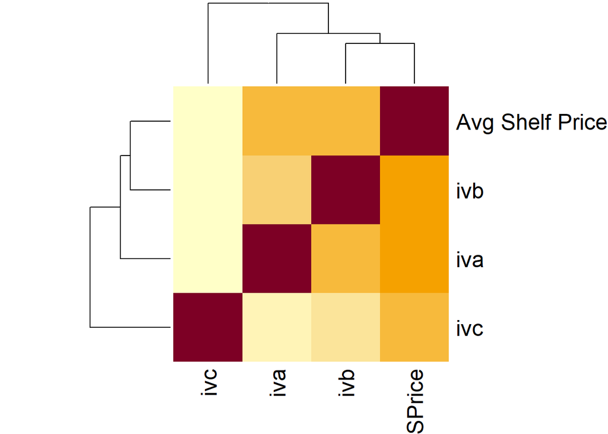

```r
# Compute correlation matrix
corr <- cor(subset(cerealdata, select = c("Avg Shelf Price", "iva", "ivb", "ivc")))

# Plot heatmap with variable names
heatmap(corr, labRow = c("Avg Shelf Price", "iva", "ivb", "ivc"),
        labCol = c("ASPrice", "iva", "ivb", "ivc"))
```

```r
#model
summary(ols2_1 <- feols(mean_utility ~ Cals + Fat + Sugar +`Avg Shelf Price`, data = cerealdata,
                     se = 'iid'))
```

```
## OLS estimation, Dep. Var.: mean_utility
## Observations: 50
## Standard-errors: IID
##                    Estimate Std. Error   t value  Pr(>|t|)
## (Intercept)       -1.761605   0.609939 -2.888166 0.0059381 **
## Cals               0.000043   0.002495  0.017160 0.9863846
## Fat               -0.000561   0.056523 -0.009931 0.9921202
## Sugar             -0.028234   0.014011 -2.015177 0.0498831 *
## `Avg Shelf Price` -0.267781   0.138457 -1.934033 0.0594128 .
## ---
## Signif. codes:  0 '***' 0.001 '**' 0.01 '*' 0.05 '.' 0.1 ' ' 1
## RMSE: 0.451604   Adj. R2: 0.102238
```

```r
summary(iv3c_1 <- feols(mean_utility ~ 1 |  `Avg Shelf Price`~ iva, data = cerealdata,
                     se = 'iid'),stage = 1:2)
```

```
## IV: First stage: `Avg Shelf Price`
## TSLS estimation - Dep. Var.: `Avg Shelf Price`
##                   Endo.    : `Avg Shelf Price`
##                   Instr.   : iva
## First stage: Dep. Var.: `Avg Shelf Price`
## Observations: 50
## Standard-errors: IID
##             Estimate Std. Error t value   Pr(>|t|)
## (Intercept) 2.255939   0.397238 5.67906 7.7228e-07 ***
## iva         0.343951   0.136380 2.52200 1.5041e-02 *
## ---
## Signif. codes:  0 '***' 0.001 '**' 0.01 '*' 0.05 '.' 0.1 ' ' 1
## RMSE: 0.489458   Adj. R2: 0.09861
## F-test (1st stage): stat = 6.36046, p = 0.015041, on 1 and 48 DoF.
##
## IV: Second stage
## TSLS estimation - Dep. Var.: mean_utility
##                   Endo.    : `Avg Shelf Price`
##                   Instr.   : iva
## Second stage: Dep. Var.: mean_utility
## Observations: 50
## Standard-errors: IID
##                        Estimate Std. Error  t value  Pr(>|t|)
## (Intercept)           -4.876437   1.740648 -2.80151 0.0073116 **
## fit_`Avg Shelf Price`  0.606663   0.536130  1.13156 0.2634412
## ---
## Signif. codes:  0 '***' 0.001 '**' 0.01 '*' 0.05 '.' 0.1 ' ' 1
## RMSE: 0.661805   Adj. R2: -0.807491
## F-test (1st stage), `Avg Shelf Price`: stat = 6.36046, p = 0.015041, on 1 and 48 DoF.
##                            Wu-Hausman: stat = 6.61965, p = 0.013304, on 1 and 47 DoF.
```

```r
summary(iv3c_2 <- feols(mean_utility ~ 1 |  `Avg Shelf Price`~ ivb, data = cerealdata,
                     se = 'iid'),stage = 1:2)
```

```
## IV: First stage: `Avg Shelf Price`
## TSLS estimation - Dep. Var.: `Avg Shelf Price`
##                   Endo.    : `Avg Shelf Price`
##                   Instr.   : ivb
## First stage: Dep. Var.: `Avg Shelf Price`
## Observations: 50
## Standard-errors: IID
##             Estimate Std. Error  t value  Pr(>|t|)
## (Intercept)  2.97251   0.123616 24.04627 < 2.2e-16 ***
## ivb          1.04052   0.393077  2.64712  0.010948 *
## ---
## Signif. codes:  0 '***' 0.001 '**' 0.01 '*' 0.05 '.' 0.1 ' ' 1
## RMSE: 0.486572   Adj. R2: 0.109208
## F-test (1st stage): stat = 7.00725, p = 0.010948, on 1 and 48 DoF.
##
## IV: Second stage
## TSLS estimation - Dep. Var.: mean_utility
##                   Endo.    : `Avg Shelf Price`
##                   Instr.   : ivb
## Second stage: Dep. Var.: mean_utility
## Observations: 50
## Standard-errors: IID
##                        Estimate Std. Error   t value Pr(>|t|)
## (Intercept)           -1.150851   1.250540 -0.920283  0.36203
## fit_`Avg Shelf Price` -0.542571   0.385122 -1.408829  0.16533
## ---
## Signif. codes:  0 '***' 0.001 '**' 0.01 '*' 0.05 '.' 0.1 ' ' 1
## RMSE: 0.496043   Adj. R2: -0.015443
## F-test (1st stage), `Avg Shelf Price`: stat = 7.00725 , p = 0.010948, on 1 and 48 DoF.
##                            Wu-Hausman: stat = 0.591994, p = 0.445499, on 1 and 47 DoF.
```

```r
summary(iv3c_3 <- feols(mean_utility ~ 1 |  `Avg Shelf Price`~ ivc, data = cerealdata,
                     se = 'iid'),stage = 1:2)
```

```
## IV: First stage: `Avg Shelf Price`
## TSLS estimation - Dep. Var.: `Avg Shelf Price`
##                   Endo.    : `Avg Shelf Price`
##                   Instr.   : ivc
## First stage: Dep. Var.: `Avg Shelf Price`
## Observations: 50
## Standard-errors: IID
##             Estimate Std. Error  t value Pr(>|t|)
## (Intercept)  2.87332   1.675058 1.715355  0.09273 .
## ivc          0.12097   0.549358 0.220202  0.82665
## ---
## Signif. codes:  0 '***' 0.001 '**' 0.01 '*' 0.05 '.' 0.1 ' ' 1
## RMSE: 0.520616   Adj. R2: -0.019803
## F-test (1st stage): stat = 0.048489, p = 0.826648, on 1 and 48 DoF.
##
## IV: Second stage
## TSLS estimation - Dep. Var.: mean_utility
##                   Endo.    : `Avg Shelf Price`
##                   Instr.   : ivc
## Second stage: Dep. Var.: mean_utility
## Observations: 50
## Standard-errors: IID
##                       Estimate Std. Error   t value Pr(>|t|)
## (Intercept)            37.2370   178.8588  0.208192  0.83596
## fit_`Avg Shelf Price` -12.3841    55.1720 -0.224464  0.82335
## ---
## Signif. codes:  0 '***' 0.001 '**' 0.01 '*' 0.05 '.' 0.1 ' ' 1
## RMSE: 6.32495   Adj. R2: -164.1
## F-test (1st stage), `Avg Shelf Price`: stat =  0.048489, p = 0.826648, on 1 and 48 DoF.
##                            Wu-Hausman: stat = 10.1     , p = 0.002594, on 1 and 47 DoF.
```

```r
summary(ols2_2 <- feols(mean_utility ~ Cals + Fat + Sugar +`Avg Shelf Price`|fbrand, data = cerealdata,
                     se = 'iid'))
```

```
## OLS estimation, Dep. Var.: mean_utility
## Observations: 50
## Fixed-effects: fbrand: 6
## Standard-errors: IID
##                    Estimate Std. Error   t value  Pr(>|t|)
## Cals               0.001039   0.002683  0.387330 0.7005651
## Fat                0.015549   0.059908  0.259545 0.7965463
## Sugar             -0.037275   0.014459 -2.577907 0.0137295 *
## `Avg Shelf Price` -0.443217   0.154931 -2.860740 0.0066887 **
## ---
## Signif. codes:  0 '***' 0.001 '**' 0.01 '*' 0.05 '.' 0.1 ' ' 1
## RMSE: 0.391354     Adj. R2: 0.241534
##                  Within R2: 0.314077
```

```r
summary(iv3c_4 <- feols(mean_utility ~ fbrand |  `Avg Shelf Price`~ iva, data = cerealdata,
                     se = 'iid'),stage = 1:2)
```

```
## IV: First stage: `Avg Shelf Price`
## TSLS estimation - Dep. Var.: `Avg Shelf Price`
##                   Endo.    : `Avg Shelf Price`
##                   Instr.   : iva
## First stage: Dep. Var.: `Avg Shelf Price`
## Observations: 50
## Standard-errors: IID
##              Estimate Std. Error   t value   Pr(>|t|)
## (Intercept)  28.47947   2.612066  10.90304 5.8672e-14 ***
## iva          -7.52683   0.787228  -9.56118 3.3100e-12 ***
## fbrandKG     -2.62944   0.258271 -10.18094 4.9949e-13 ***
## fbrandNB    -10.22521   1.032761  -9.90085 1.1671e-12 ***
## fbrandPT     -5.93515   0.591083 -10.04114 7.6199e-13 ***
## fbrandQK    -12.04940   1.160840 -10.37990 2.7501e-13 ***
## fbrandRL    -11.99805   1.265029  -9.48440 4.1978e-12 ***
## ---
## Signif. codes:  0 '***' 0.001 '**' 0.01 '*' 0.05 '.' 0.1 ' ' 1
## RMSE: 0.246575   Adj. R2: 0.744641
## F-test (1st stage): stat = 91.4, p = 3.31e-12, on 1 and 43 DoF.
##
## IV: Second stage
## TSLS estimation - Dep. Var.: mean_utility
##                   Endo.    : `Avg Shelf Price`
##                   Instr.   : iva
## Second stage: Dep. Var.: mean_utility
## Observations: 50
## Standard-errors: IID
##                        Estimate Std. Error   t value Pr(>|t|)
## (Intercept)           -1.529325   0.645172 -2.370414 0.022322 *
## fit_`Avg Shelf Price` -0.397083   0.181077 -2.192897 0.033772 *
## fbrandKG               0.075634   0.165779  0.456233 0.650519
## fbrandNB              -0.277851   0.299881 -0.926539 0.359338
## fbrandPT              -0.338672   0.229483 -1.475803 0.147283
## fbrandQK              -0.660875   0.316536 -2.087831 0.042773 *
## fbrandRL              -0.217531   0.343244 -0.633751 0.529600
## ---
## Signif. codes:  0 '***' 0.001 '**' 0.01 '*' 0.05 '.' 0.1 ' ' 1
## RMSE: 0.426897   Adj. R2: 0.160471
## F-test (1st stage), `Avg Shelf Price`: stat = 91.4     , p = 3.31e-12, on 1 and 43 DoF.
##                            Wu-Hausman: stat =  0.510646, p = 0.478813, on 1 and 42 DoF.
```

```r
summary(iv3c_5 <- feols(mean_utility ~ fbrand |  `Avg Shelf Price`~ ivb, data = cerealdata,
                     se = 'iid'),stage = 1:2)
```

```
## IV: First stage: `Avg Shelf Price`
## TSLS estimation - Dep. Var.: `Avg Shelf Price`
##                   Endo.    : `Avg Shelf Price`
##                   Instr.   : ivb
## First stage: Dep. Var.: `Avg Shelf Price`
## Observations: 50
## Standard-errors: IID
##              Estimate Std. Error   t value   Pr(>|t|)
## (Intercept)  3.209507   0.158976 20.188664  < 2.2e-16 ***
## ivb          0.934626   0.372589  2.508460 0.01597731 *
## fbrandKG    -0.203184   0.154991 -1.310935 0.19683784
## fbrandNB    -0.388022   0.276195 -1.404887 0.16723811
## fbrandPT    -0.400799   0.207030 -1.935944 0.05946620 .
## fbrandQK    -0.947298   0.245487 -3.858860 0.00037712 ***
## fbrandRL     0.166376   0.338668  0.491267 0.62573615
## ---
## Signif. codes:  0 '***' 0.001 '**' 0.01 '*' 0.05 '.' 0.1 ' ' 1
## RMSE: 0.407178   Adj. R2: 0.303658
## F-test (1st stage): stat = 6.29237, p = 0.015977, on 1 and 43 DoF.
##
## IV: Second stage
## TSLS estimation - Dep. Var.: mean_utility
##                   Endo.    : `Avg Shelf Price`
##                   Instr.   : ivb
## Second stage: Dep. Var.: mean_utility
## Observations: 50
## Standard-errors: IID
##                        Estimate Std. Error   t value Pr(>|t|)
## (Intercept)           -0.841391   1.479322 -0.568768 0.572473
## fit_`Avg Shelf Price` -0.592952   0.420047 -1.411634 0.165253
## fbrandKG               0.014018   0.204795  0.068450 0.945744
## fbrandNB              -0.371650   0.351708 -1.056702 0.296548
## fbrandPT              -0.419413   0.278468 -1.506143 0.139342
## fbrandQK              -0.864524   0.506096 -1.708219 0.094806 .
## fbrandRL              -0.227760   0.345526 -0.659169 0.513302
## ---
## Signif. codes:  0 '***' 0.001 '**' 0.01 '*' 0.05 '.' 0.1 ' ' 1
## RMSE: 0.429031   Adj. R2: 0.152056
## F-test (1st stage), `Avg Shelf Price`: stat = 6.29237 , p = 0.015977, on 1 and 43 DoF.
##                            Wu-Hausman: stat = 0.096901, p = 0.75712 , on 1 and 42 DoF.
```

```r
summary(iv3c_6 <- feols(mean_utility ~ fbrand |  `Avg Shelf Price`~ ivc, data = cerealdata,
                     se = 'iid'),stage = 1:2)
```

```
## IV: First stage: `Avg Shelf Price`
## TSLS estimation - Dep. Var.: `Avg Shelf Price`
##                   Endo.    : `Avg Shelf Price`
##                   Instr.   : ivc
## First stage: Dep. Var.: `Avg Shelf Price`
## Observations: 50
## Standard-errors: IID
##              Estimate Std. Error   t value   Pr(>|t|)
## (Intercept)  0.767455   1.547280  0.496003 6.2242e-01
## ivc          0.907144   0.510152  1.778184 8.2445e-02 .
## fbrandKG    -0.298941   0.153698 -1.944989 5.8334e-02 .
## fbrandNB    -0.524014   0.284077 -1.844622 7.1988e-02 .
## fbrandPT    -0.470493   0.216379 -2.174394 3.5224e-02 *
## fbrandQK    -1.200621   0.266624 -4.503052 5.0578e-05 ***
## fbrandRL    -0.081865   0.338590 -0.241783 8.1010e-01
## ---
## Signif. codes:  0 '***' 0.001 '**' 0.01 '*' 0.05 '.' 0.1 ' ' 1
## RMSE: 0.420758   Adj. R2: 0.256436
## F-test (1st stage): stat = 3.16194, p = 0.082445, on 1 and 43 DoF.
##
## IV: Second stage
## TSLS estimation - Dep. Var.: mean_utility
##                   Endo.    : `Avg Shelf Price`
##                   Instr.   : ivc
## Second stage: Dep. Var.: mean_utility
## Observations: 50
## Standard-errors: IID
##                        Estimate Std. Error   t value Pr(>|t|)
## (Intercept)            2.259418   2.872371  0.786604 0.435828
## fit_`Avg Shelf Price` -1.475814   0.816625 -1.807211 0.077729 .
## fbrandKG              -0.263708   0.340061 -0.775473 0.442304
## fbrandNB              -0.794443   0.567226 -1.400577 0.168516
## fbrandPT              -0.783349   0.458019 -1.710296 0.094418 .
## fbrandQK              -1.782455   0.923874 -1.929327 0.060306 .
## fbrandRL              -0.273865   0.492921 -0.555596 0.581367
## ---
## Signif. codes:  0 '***' 0.001 '**' 0.01 '*' 0.05 '.' 0.1 ' ' 1
## RMSE: 0.610986   Adj. R2: -0.719698
## F-test (1st stage), `Avg Shelf Price`: stat = 3.16194, p = 0.082445, on 1 and 43 DoF.
##                            Wu-Hausman: stat = 3.55038, p = 0.066466, on 1 and 42 DoF.
```

```r
gof <- data.frame(raw = c("nobs", "adj.r.squared"),
                  clean = c("Observations", "R2 adj."),
                  fmt = c(0, 3))
fe <- data.frame(FE = c("Brand FE", "Instruments"),
                 mod1 = c("No", "None"),
                 mod2 = c("No", "IVA"),
                 mod3 = c("No", "IVB"),
                 mod4 = c("No", "IVC"),
                mod5 = c("Yes", "None"),
                mod6 = c("Yes", "IVA"),
                mod7 = c("Yes", "IVB"),
                mod8 = c("Yes", "IVC"))

attr(fe, "position") <- c(23, 24)

modelsummary(list(ols2_1, iv3c_1,iv3c_2,iv3c_3, ols2_2,iv3c_4,iv3c_5,iv3c_6),
              stars = c("*" = .1, "**" = .05, "***" = .01),
              gof_map = gof, add_rows = fe, output = "markdown")
```

|  | (1) | (2) | (3) | (4) | (5) | (6) | (7) | (8) |
| --- | --- | --- | --- | --- | --- | --- | --- | --- |
| (Intercept) | -1.762*** | -4.876*** | -1.151 | 37.237 |  | -1.529** | -0.841 | 2.259 |
|  | (0.610) | (1.741) | (1.251) | (178.859) |  | (0.645) | (1.479) | (2.872) |
| Cals | 0.000 |  |  |  | 0.001 |  |  |  |
|  | (0.002) |  |  |  | (0.003) |  |  |  |
| Fat | -0.001 |  |  |  | 0.016 |  |  |  |
|  | (0.057) |  |  |  | (0.060) |  |  |  |
| Sugar | -0.028** |  |  |  | -0.037** |  |  |  |
|  | (0.014) |  |  |  | (0.014) |  |  |  |
| Avg Shelf Price | -0.268* |  |  |  | -0.443*** |  |  |  |
|  | (0.138) |  |  |  | (0.155) |  |  |  |
| fit_Avg Shelf Price |  | 0.607 | -0.543 | -12.384 |  | -0.397** | -0.593 | -1.476* |
|  |  | (0.536) | (0.385) | (55.172) |  | (0.181) | (0.420) | (0.817) |
| fbrandKG |  |  |  |  |  | 0.076 | 0.014 | -0.264 |
|  |  |  |  |  |  | (0.166) | (0.205) | (0.340) |
| fbrandNB |  |  |  |  |  | -0.278 | -0.372 | -0.794 |
|  |  |  |  |  |  | (0.300) | (0.352) | (0.567) |
| fbrandPT |  |  |  |  |  | -0.339 | -0.419 | -0.783* |
|  |  |  |  |  |  | (0.229) | (0.278) | (0.458) |
| fbrandQK |  |  |  |  |  | -0.661** | -0.865* | -1.782* |
|  |  |  |  |  |  | (0.317) | (0.506) | (0.924) |
| fbrandRL |  |  |  |  |  | -0.218 | -0.228 | -0.274 |
|  |  |  |  |  |  | (0.343) | (0.346) | (0.493) |
| Brand FE | No | No | No | No | Yes | Yes | Yes | Yes |
| Instruments | None | IVA | IVB | IVC | None | IVA | IVB | IVC |
| Observations | 50 | 50 | 50 | 50 | 50 | 50 | 50 | 50 |
| R2 adj. | 0.102 | -0.807 | -0.015 | -164.094 | 0.242 | 0.160 | 0.152 | -0.720 |

* p < 0.1, ** p < 0.05, *** p < 0.01

```r
fitstat(iv3c_1, ~ ivwald1 + ivf1 + kpr + sargan)
```

```
## Wald (1st stage), `Avg Shelf Price`  : stat = 6.36046 , p = 0.015041, on 1 and 48 DoF, VCOV: IID.
## F-test (1st stage), `Avg Shelf Price`: stat = 6.36046 , p = 0.015041, on 1 and 48 DoF.
##                       Kleibergen-Paap: stat = 0.936985, p = 0.333055, on 1 DoF.
##                                Sargan: NA
```

```r
fitstat(iv3c_2, ~ ivwald1 + ivf1 + kpr + sargan)
```

```
## Wald (1st stage), `Avg Shelf Price`  : stat = 7.00725, p = 0.010948, on 1 and 48 DoF, VCOV: IID.
## F-test (1st stage), `Avg Shelf Price`: stat = 7.00725, p = 0.010948, on 1 and 48 DoF.
##                       Kleibergen-Paap: stat = 1.03227, p = 0.309627, on 1 DoF.
##                                Sargan: NA
```

```r
fitstat(iv3c_3, ~ ivwald1 + ivf1 + kpr + sargan)
```

```
## Wald (1st stage), `Avg Shelf Price`  : stat = 0.048489, p = 0.826648, on 1 and 48 DoF, VCOV: IID.
## F-test (1st stage), `Avg Shelf Price`: stat = 0.048489, p = 0.826648, on 1 and 48 DoF.
##                       Kleibergen-Paap: stat = 0.007143, p = 0.932646, on 1 DoF.
##                                Sargan: NA
```

```r
fitstat(iv3c_4, ~ ivwald1 + ivf1 + kpr + sargan)
```

```
## Wald (1st stage), `Avg Shelf Price`  : stat = 91.4, p = 3.31e-12, on 1 and 43 DoF, VCOV: IID.
## F-test (1st stage), `Avg Shelf Price`: stat = 91.4, p = 3.31e-12, on 1 and 43 DoF.
##                       Kleibergen-Paap: stat = 15.0, p = 1.057e-4, on 1 DoF.
##                                Sargan: NA
```

```r
fitstat(iv3c_5, ~ ivwald1 + ivf1 + kpr + sargan)
```

```
## Wald (1st stage), `Avg Shelf Price`  : stat = 6.29237, p = 0.015977, on 1 and 43 DoF, VCOV: IID.
## F-test (1st stage), `Avg Shelf Price`: stat = 6.29237, p = 0.015977, on 1 and 43 DoF.
##                       Kleibergen-Paap: stat = 1.03474, p = 0.309048, on 1 DoF.
##                                Sargan: NA
```

```r
fitstat(iv3c_6, ~ ivwald1 + ivf1 + kpr + sargan)
```

```
## Wald (1st stage), `Avg Shelf Price`  : stat = 3.16194, p = 0.082445, on 1 and 43 DoF, VCOV: IID.
## F-test (1st stage), `Avg Shelf Price`: stat = 3.16194, p = 0.082445, on 1 and 43 DoF.
##                       Kleibergen-Paap: stat = 0.51996, p = 0.470859, on 1 DoF.
##                                Sargan: NA
```

#interaction

```r
summary(ols2_1 <- feols(mean_utility ~ Cals + Fat + Sugar +`Avg Shelf Price`,
                        data = cerealdata, se = 'iid'))
```

```
## OLS estimation, Dep. Var.: mean_utility
## Observations: 50
## Standard-errors: IID
##                    Estimate Std. Error   t value  Pr(>|t|)
## (Intercept)       -1.761605   0.609939 -2.888166 0.0059381 **
## Cals               0.000043   0.002495  0.017160 0.9863846
## Fat               -0.000561   0.056523 -0.009931 0.9921202
## Sugar             -0.028234   0.014011 -2.015177 0.0498831 *
## `Avg Shelf Price` -0.267781   0.138457 -1.934033 0.0594128 .
## ---
## Signif. codes:  0 '***' 0.001 '**' 0.01 '*' 0.05 '.' 0.1 ' ' 1
## RMSE: 0.451604   Adj. R2: 0.102238
```

```r
summary(iv4c_1 <- feols(mean_utility ~ 1 |  `Avg Shelf Price`~ iva +  ivb + ivc,
                        data = cerealdata, se = 'iid'),stage = 1:2)
```

```
## IV: First stage: `Avg Shelf Price`
## TSLS estimation - Dep. Var.: `Avg Shelf Price`
##                   Endo.    : `Avg Shelf Price`
##                   Instr.   : iva, ivb, ivc
## First stage: Dep. Var.: `Avg Shelf Price`
## Observations: 50
## Standard-errors: IID
##              Estimate Std. Error   t value Pr(>|t|)
## (Intercept) -0.239607   1.745159 -0.137298 0.891395
## iva          0.349348   0.136923  2.551422 0.014118 *
## ivb          0.960373   0.381827  2.515205 0.015453 *
## ivc          0.732597   0.517776  1.414891 0.163834
## ---
## Signif. codes:  0 '***' 0.001 '**' 0.01 '*' 0.05 '.' 0.1 ' ' 1
## RMSE: 0.453336   Adj. R2: 0.193128
## F-test (1st stage): stat = 4.90945, p = 0.004831, on 3 and 46 DoF.
##
## IV: Second stage
## TSLS estimation - Dep. Var.: mean_utility
##                   Endo.    : `Avg Shelf Price`
##                   Instr.   : iva, ivb, ivc
## Second stage: Dep. Var.: mean_utility
## Observations: 50
## Standard-errors: IID
##                        Estimate Std. Error  t value Pr(>|t|)
## (Intercept)           -2.009077   0.871299 -2.30584 0.025484 *
## fit_`Avg Shelf Price` -0.277834   0.267933 -1.03695 0.304954
## ---
## Signif. codes:  0 '***' 0.001 '**' 0.01 '*' 0.05 '.' 0.1 ' ' 1
## RMSE: 0.476173   Adj. R2: 0.064282
## F-test (1st stage), `Avg Shelf Price`: stat =  4.90945 , p = 0.004831, on 3 and 46 DoF.
##                            Wu-Hausman: stat =  8.026e-5, p = 0.99289 , on 1 and 47 DoF.
##                                Sargan: stat = 13.0     , p = 0.001471, on 2 DoF.
```

```r
summary(ols2_2 <- feols(mean_utility ~ Cals + Fat + Sugar +`Avg Shelf Price`|fbrand,
                        data = cerealdata,se = 'iid'))
```

```
## OLS estimation, Dep. Var.: mean_utility
## Observations: 50
## Fixed-effects: fbrand: 6
## Standard-errors: IID
##                    Estimate Std. Error   t value  Pr(>|t|)
## Cals               0.001039   0.002683  0.387330 0.7005651
## Fat                0.015549   0.059908  0.259545 0.7965463
## Sugar             -0.037275   0.014459 -2.577907 0.0137295 *
## `Avg Shelf Price` -0.443217   0.154931 -2.860740 0.0066887 **
## ---
## Signif. codes:  0 '***' 0.001 '**' 0.01 '*' 0.05 '.' 0.1 ' ' 1
## RMSE: 0.391354     Adj. R2: 0.241534
##                  Within R2: 0.314077
```

```r
summary(iv4c_2 <- feols(mean_utility ~ fbrand |  `Avg Shelf Price`~ iva + ivb +ivc,
                        data = cerealdata, se = 'iid'),stage = 1:2)
```

```
## IV: First stage: `Avg Shelf Price`
## TSLS estimation - Dep. Var.: `Avg Shelf Price`
##                   Endo.    : `Avg Shelf Price`
##                   Instr.   : iva, ivb, ivc
## First stage: Dep. Var.: `Avg Shelf Price`
## Observations: 50
## Standard-errors: IID
##               Estimate Std. Error  t value   Pr(>|t|)
## (Intercept)  24.334543   3.092922  7.86782 1.0096e-09 ***
## iva          -6.898562   0.825861 -8.35317 2.1802e-10 ***
## ivb           0.335141   0.238589  1.40468 1.6765e-01
## ivc           0.645248   0.298977  2.15819 3.6821e-02 *
## fbrandKG     -2.385154   0.280972 -8.48894 1.4263e-10 ***
## fbrandNB     -9.411189   1.087122 -8.65697 8.4593e-11 ***
## fbrandPT     -5.511500   0.615284 -8.95766 3.3486e-11 ***
## fbrandQK    -11.211718   1.215269 -9.22571 1.4790e-11 ***
## fbrandRL    -10.943620   1.344465 -8.13976 4.2648e-10 ***
## ---
## Signif. codes:  0 '***' 0.001 '**' 0.01 '*' 0.05 '.' 0.1 ' ' 1
## RMSE: 0.231579   Adj. R2: 0.76377
## F-test (1st stage): stat = 34.8, p = 2.419e-11, on 3 and 41 DoF.
##
## IV: Second stage
## TSLS estimation - Dep. Var.: mean_utility
##                   Endo.    : `Avg Shelf Price`
##                   Instr.   : iva, ivb, ivc
## Second stage: Dep. Var.: mean_utility
## Observations: 50
## Standard-errors: IID
##                        Estimate Std. Error   t value  Pr(>|t|)
## (Intercept)           -1.228301   0.626763 -1.959754 0.0565265 .
## fit_`Avg Shelf Price` -0.482791   0.175772 -2.746682 0.0087573 **
## fbrandKG               0.048672   0.164812  0.295320 0.7691707
## fbrandNB              -0.318895   0.298403 -1.068674 0.2911795
## fbrandPT              -0.374002   0.228218 -1.638790 0.1085544
## fbrandQK              -0.749987   0.312723 -2.398249 0.0208848 *
## fbrandRL              -0.222007   0.342299 -0.648577 0.5200606
## ---
## Signif. codes:  0 '***' 0.001 '**' 0.01 '*' 0.05 '.' 0.1 ' ' 1
## RMSE: 0.42573   Adj. R2: 0.165055
## F-test (1st stage), `Avg Shelf Price`: stat = 34.8     , p = 2.419e-11, on 3 and 41 DoF.
##                            Wu-Hausman: stat =  0.016982, p = 0.896941 , on 1 and 42 DoF.
##                                Sargan: stat =  5.12687 , p = 0.07704  , on 2 DoF.
```

```r
gof <- data.frame(raw = c("nobs", "adj.r.squared"),
                  clean = c("Observations", "R2 adj."),
                  fmt = c(0, 3))
fe <- data.frame(FE = c("Brand FE", "Instruments"),
                 mod1 = c("No", "None"),
                 mod2 = c("No", "IVA+IVB+IVC"),
                 mod3 = c("Yes", "None"),
                 mod4 = c("Yes", "IVA+IVB+IVC"))

attr(fe, "position") <- c(23, 24)

modelsummary(list(ols2_1, iv4c_1, ols2_2, iv4c_2),
              stars = c("*" = .1, "**" = .05, "***" = .01),
              gof_map = gof, add_rows = fe, output = "markdown")
```

|  | (1) | (2) | (3) | (4) |
| --- | --- | --- | --- | --- |
| (Intercept) | -1.762*** | -2.009** |  | -1.228* |
|  | (0.610) | (0.871) |  | (0.627) |
| Cals | 0.000 |  | 0.001 |  |
|  | (0.002) |  | (0.003) |  |
| Fat | -0.001 |  | 0.016 |  |
|  | (0.057) |  | (0.060) |  |
| Sugar | -0.028** |  | -0.037** |  |
|  | (0.014) |  | (0.014) |  |
| Avg Shelf Price | -0.268* |  | -0.443*** |  |
|  | (0.138) |  | (0.155) |  |
| fit_Avg Shelf Price |  | -0.278 |  | -0.483*** |
|  |  | (0.268) |  | (0.176) |
| fbrandKG |  |  |  | 0.049 |
|  |  |  |  | (0.165) |
| fbrandNB |  |  |  | -0.319 |
|  |  |  |  | (0.298) |
| fbrandPT |  |  |  | -0.374 |
|  |  |  |  | (0.228) |
| fbrandQK |  |  |  | -0.750** |
|  |  |  |  | (0.313) |
| fbrandRL |  |  |  | -0.222 |
|  |  |  |  | (0.342) |
| Brand FE | No | No | Yes | Yes |
| Instruments | None | IVA+IVB+IVC | None | IVA+IVB+IVC |
| Observations | 50 | 50 | 50 | 50 |
| R2 adj. | 0.102 | 0.064 | 0.242 | 0.165 |

* p < 0.1, ** p < 0.05, *** p < 0.01

```r
fitstat(iv4c_1, ~ ivwald1 + ivf1 + kpr + sargan)
```

```
## Wald (1st stage), `Avg Shelf Price`  : stat =  4.90945 , p = 0.004831, on 3 and 46 DoF, VCOV: IID.
## F-test (1st stage), `Avg Shelf Price`: stat =  4.90945 , p = 0.004831, on 3 and 46 DoF.
##                       Kleibergen-Paap: stat =  0.754674, p = 0.860275, on 3 DoF.
##                                Sargan: stat = 13.0     , p = 0.001471, on 2 DoF.
```

```r
fitstat(iv4c_2, ~ ivwald1 + ivf1 + kpr + sargan)
```

```
## Wald (1st stage), `Avg Shelf Price`  : stat = 34.8    , p = 2.419e-11, on 3 and 41 DoF, VCOV: IID.
## F-test (1st stage), `Avg Shelf Price`: stat = 34.8    , p = 2.419e-11, on 3 and 41 DoF.
##                       Kleibergen-Paap: stat =  5.99605, p = 0.111803 , on 3 DoF.
##                                Sargan: stat =  5.12687, p = 0.07704  , on 2 DoF.
```

# TASK 5

**Thinking out of the matrix. In case you didn’t get a satisfactory specification up to now, can you suggest any improvements? Hint: One improvement comes from a new variable. Another improvement comes from tackling the IIA property of logit models. As a guidance, When reporting, please include again the following specifications previously reported: (i) your preferred OLS logit specifications with and without brand FEs; (ii) your preferred IV logit specification with and without brand FEs which include all instruments.**

The “IIA property” refers to the Independence of Irrelevant Alternatives, which is a key assumption in multinomial logit models. This assumption states that the odds of choosing one alternative over another are unaffected by the presence or absence of other alternatives in the choice set.

However, the IIA property is often criticized because it can lead to unrealistic modeling assumptions. When the IIA property is violated, it implies that the relative attractiveness of alternatives is influenced by the inclusion or exclusion of irrelevant alternatives in the choice set. This can result in biased model estimates and misleading predictions.

There are several techniques to address or mitigate violations of the IIA property:

1. **Nested Logit Models**: These models relax the assumption of independence by allowing for correlation within subsets of alternatives. Alternatives are grouped into nested subsets based on similarities or shared characteristics. This allows for more flexibility in capturing heterogeneity in preferences.

```r
# Create dummy variable for sugar
cerealdata$sugar_dummy <- ifelse(cerealdata$Sugar >= 1, 1, 0)

#withouth brand fix effect baseline model
ols_1o <- feols(mean_utility ~ Cals + Fat + Sugar + `Avg Shelf Price`, data = cerealdata,
                se = 'iid')
summary(ols_1o)
```

```
## OLS estimation, Dep. Var.: mean_utility
## Observations: 50
## Standard-errors: IID
##                    Estimate Std. Error   t value  Pr(>|t|)
## (Intercept)       -1.761605   0.609939 -2.888166 0.0059381 **
## Cals               0.000043   0.002495  0.017160 0.9863846
## Fat               -0.000561   0.056523 -0.009931 0.9921202
## Sugar             -0.028234   0.014011 -2.015177 0.0498831 *
## `Avg Shelf Price` -0.267781   0.138457 -1.934033 0.0594128 .
## ---
## Signif. codes:  0 '***' 0.001 '**' 0.01 '*' 0.05 '.' 0.1 ' ' 1
## RMSE: 0.451604   Adj. R2: 0.102238
```

```r
#new variable
ols_1n <- feols(mean_utility ~ Cals + Fat + Sugar + `Avg Shelf Price` + sugar_dummy, data = cerealdata,
                se = 'iid')
summary(ols_1n)
```

```
## OLS estimation, Dep. Var.: mean_utility
## Observations: 50
## Standard-errors: IID
##                    Estimate Std. Error   t value  Pr(>|t|)
## (Intercept)       -2.170164   0.682546 -3.179515 0.0027014 **
## Cals               0.000912   0.002566  0.355400 0.7239884
## Fat               -0.012351   0.056834 -0.217320 0.8289633
## Sugar             -0.038819   0.016127 -2.407061 0.0203443 *
## `Avg Shelf Price` -0.267059   0.137425 -1.943311 0.0583928 .
## sugar_dummy        0.431503   0.332946  1.296014 0.2017279
## ---
## Signif. codes:  0 '***' 0.001 '**' 0.01 '*' 0.05 '.' 0.1 ' ' 1
## RMSE: 0.443224   Adj. R2: 0.115595
```

```r
#with brand fix effect baseline model
ols_4o <- feols(mean_utility ~ Cals + Fat + Sugar + `Avg Shelf Price` | fbrand, data = cerealdata,
                se = 'iid')
summary(ols_4o)
```

```
## OLS estimation, Dep. Var.: mean_utility
## Observations: 50
## Fixed-effects: fbrand: 6
## Standard-errors: IID
##                    Estimate Std. Error   t value  Pr(>|t|)
## Cals               0.001039   0.002683  0.387330 0.7005651
## Fat                0.015549   0.059908  0.259545 0.7965463
## Sugar             -0.037275   0.014459 -2.577907 0.0137295 *
## `Avg Shelf Price` -0.443217   0.154931 -2.860740 0.0066887 **
## ---
## Signif. codes:  0 '***' 0.001 '**' 0.01 '*' 0.05 '.' 0.1 ' ' 1
## RMSE: 0.391354     Adj. R2: 0.241534
##                  Within R2: 0.314077
```

```r
#new variable
ols_4n <- feols(mean_utility ~ Cals + Fat + Sugar + `Avg Shelf Price` + sugar_dummy | fbrand, data = cerealdata,
                se = 'iid')
summary(ols_4n)
```

```
## OLS estimation, Dep. Var.: mean_utility
## Observations: 50
## Fixed-effects: fbrand: 6
## Standard-errors: IID
##                    Estimate Std. Error   t value  Pr(>|t|)
## Cals               0.001226   0.002699  0.454116 0.6522628
## Fat                0.015201   0.060092  0.252968 0.8016217
## Sugar             -0.042151   0.015548 -2.711013 0.0099219 **
## `Avg Shelf Price` -0.442477   0.155405 -2.847250 0.0069996 **
## sugar_dummy        0.324738   0.373145  0.870275 0.3894755
## ---
## Signif. codes:  0 '***' 0.001 '**' 0.01 '*' 0.05 '.' 0.1 ' ' 1
## RMSE: 0.387608     Adj. R2: 0.236905
##                  Within R2: 0.327144
```

```r
# without fe  iv1a_2 Average advert Expenditure*brand

summary(iv1a_2o <- feols(mean_utility ~ Cals + Fat + Sugar | `Avg Shelf Price` ~ `Avg Ad Expn`:fbrand, data = cerealdata, se = 'iid'))
```

```
## TSLS estimation - Dep. Var.: mean_utility
##                   Endo.    : `Avg Shelf Price`
##                   Instr.   : `Avg Ad Expn`:fbrand
## Second stage: Dep. Var.: mean_utility
## Observations: 50
## Standard-errors: IID
##                        Estimate Std. Error   t value Pr(>|t|)
## (Intercept)           -0.478423   1.173293 -0.407761 0.685383
## fit_`Avg Shelf Price` -0.597983   0.291552 -2.051032 0.046113 *
## Cals                  -0.001983   0.003066 -0.646822 0.521033
## Fat                    0.017643   0.061574  0.286537 0.775782
## Sugar                 -0.022990   0.015398 -1.493041 0.142405
## ---
## Signif. codes:  0 '***' 0.001 '**' 0.01 '*' 0.05 '.' 0.1 ' ' 1
## RMSE: 0.479295   Adj. R2: -0.01123
## F-test (1st stage), `Avg Shelf Price`: stat =  2.27027, p = 0.055895, on 6 and 40 DoF.
##                            Wu-Hausman: stat =  1.97898, p = 0.166522, on 1 and 44 DoF.
##                                Sargan: stat = 29.9    , p = 1.567e-5, on 5 DoF.
```

```r
#without fe  iv1a_2 Average advert Expenditure*brand
summary(iv1a_2n <- feols(mean_utility ~ Cals + Fat + Sugar + sugar_dummy | `Avg Shelf Price` ~ `Avg Ad Expn`:fbrand, data = cerealdata, se = 'iid'))
```

```
## TSLS estimation - Dep. Var.: mean_utility
##                   Endo.    : `Avg Shelf Price`
##                   Instr.   : `Avg Ad Expn`:fbrand
## Second stage: Dep. Var.: mean_utility
## Observations: 50
## Standard-errors: IID
##                        Estimate Std. Error   t value Pr(>|t|)
## (Intercept)           -0.814535   1.219810 -0.667755 0.507777
## fit_`Avg Shelf Price` -0.615076   0.290728 -2.115642 0.040071 *
## Cals                  -0.001230   0.003150 -0.390498 0.698053
## Fat                    0.006929   0.062401  0.111037 0.912092
## Sugar                 -0.033208   0.017729 -1.873038 0.067716 .
## sugar_dummy            0.428083   0.356394  1.201152 0.236118
## ---
## Signif. codes:  0 '***' 0.001 '**' 0.01 '*' 0.05 '.' 0.1 ' ' 1
## RMSE: 0.474426   Adj. R2: -0.01331
## F-test (1st stage), `Avg Shelf Price`: stat =  2.23661, p = 0.059767, on 6 and 39 DoF.
##                            Wu-Hausman: stat =  2.27044, p = 0.139174, on 1 and 43 DoF.
##                                Sargan: stat = 29.5    , p = 1.83e-5 , on 5 DoF.
```

```r
# with fe  iv1a_6 Average transaction price*brand

summary(iv2a_6o <- feols(mean_utility ~ Cals + Fat + Sugar | fbrand | `Avg Shelf Price` ~ `Avg Trans Price`:fbrand,
                        data = cerealdata, se = 'iid'))
```

```
## TSLS estimation - Dep. Var.: mean_utility
##                   Endo.    : `Avg Shelf Price`
##                   Instr.   : `Avg Trans Price`:fbrand
## Second stage: Dep. Var.: mean_utility
## Observations: 50
## Fixed-effects: fbrand: 6
## Standard-errors: IID
##                        Estimate Std. Error   t value Pr(>|t|)
## fit_`Avg Shelf Price` -0.409198   0.169093 -2.419955 0.020159 *
## Cals                   0.001275   0.002725  0.467916 0.642384
## Fat                    0.011934   0.060372  0.197672 0.844303
## Sugar                 -0.037855   0.014514 -2.608192 0.012736 *
## ---
## Signif. codes:  0 '***' 0.001 '**' 0.01 '*' 0.05 '.' 0.1 ' ' 1
## RMSE: 0.391589     Adj. R2: 0.24062
##                  Within R2: 0.31325
## F-test (1st stage), `Avg Shelf Price`: stat = 30.7     , p = 1.451e-12, on 6 and 35 DoF.
##                            Wu-Hausman: stat =  0.249329, p = 0.620353 , on 1 and 39 DoF.
##                                Sargan: stat =  9.92037 , p = 0.077523 , on 5 DoF.
```

```r
# with fe  iv1a_6 Average transaction price*brand

summary(iv2a_6n <- feols(mean_utility ~ Cals + Fat + Sugar +sugar_dummy| fbrand | `Avg Shelf Price` ~ `Avg Trans Price`:fbrand,
                        data = cerealdata, se = 'iid'))
```

```
## TSLS estimation - Dep. Var.: mean_utility
##                   Endo.    : `Avg Shelf Price`
##                   Instr.   : `Avg Trans Price`:fbrand
## Second stage: Dep. Var.: mean_utility
## Observations: 50
## Fixed-effects: fbrand: 6
## Standard-errors: IID
##                        Estimate Std. Error   t value  Pr(>|t|)
## fit_`Avg Shelf Price` -0.409329   0.169602 -2.413474 0.0205978 *
## Cals                   0.001456   0.002741  0.531064 0.5983862
## Fat                    0.011679   0.060556  0.192856 0.8480729
## Sugar                 -0.042723   0.015601 -2.738469 0.0092547 **
## sugar_dummy            0.325173   0.373363  0.870931 0.3891216
## ---
## Signif. codes:  0 '***' 0.001 '**' 0.01 '*' 0.05 '.' 0.1 ' ' 1
## RMSE: 0.387834     Adj. R2: 0.236015
##                  Within R2: 0.326359
## F-test (1st stage), `Avg Shelf Price`: stat = 29.9     , p = 3.426e-12, on 6 and 34 DoF.
##                            Wu-Hausman: stat =  0.235177, p = 0.630496 , on 1 and 38 DoF.
##                                Sargan: stat =  9.76204 , p = 0.082265 , on 5 DoF.
```

```r
gof <- data.frame(raw = c("nobs", "adj.r.squared"),
                  clean = c("Observations", "R2 adj."),
                  fmt = c(0, 3))
fe <- data.frame(FE = c("Brand FE", "Instruments","New variable"),
                 mod1 = c("No", "None","No"),
                 mod2 = c("No", "None","Yes"),
                 mod3 = c("Yes", "None","No"),
                 mod4 = c("Yes", "None","Yes"),
                 mod5 = c("No", "Average advert Expenditure*brand","No"),
                 mod6 = c("No", "Average advert Expenditure*brand","Yes"),
                 mod7 = c("Yes", "Average Avg Trans Price*brand","No"),
                 mod8 = c("Yes", "Average Avg Trans Price*brand","Yes"))


attr(fe, "position") <- c(15, 16)

modelsummary(list(ols_1o, ols_1n, ols_4o, ols_4n, iv1a_2o, iv1a_2n, iv2a_6o, iv2a_6n),
              stars = c("*" = .1, "**" = .05, "***" = .01),
              gof_map = gof, add_rows = fe, output = "markdown")
```

|  | (1) | (2) | (3) | (4) | (5) | (6) | (7) | (8) |
| --- | --- | --- | --- | --- | --- | --- | --- | --- |
| (Intercept) | -1.762*** | -2.170*** |  |  | -0.478 | -0.815 |  |  |
|  | (0.610) | (0.683) |  |  | (1.173) | (1.220) |  |  |
| Cals | 0.000 | 0.001 | 0.001 | 0.001 | -0.002 | -0.001 | 0.001 | 0.001 |
|  | (0.002) | (0.003) | (0.003) | (0.003) | (0.003) | (0.003) | (0.003) | (0.003) |
| Fat | -0.001 | -0.012 | 0.016 | 0.015 | 0.018 | 0.007 | 0.012 | 0.012 |
|  | (0.057) | (0.057) | (0.060) | (0.060) | (0.062) | (0.062) | (0.060) | (0.061) |
| Sugar | -0.028** | -0.039** | -0.037** | -0.042*** | -0.023 | -0.033* | -0.038** | -0.043*** |
|  | (0.014) | (0.016) | (0.014) | (0.016) | (0.015) | (0.018) | (0.015) | (0.016) |
| Avg Shelf Price | -0.268* | -0.267* | -0.443*** | -0.442*** |  |  |  |  |
|  | (0.138) | (0.137) | (0.155) | (0.155) |  |  |  |  |
| sugar_dummy |  | 0.432 |  | 0.325 |  | 0.428 |  | 0.325 |
|  |  | (0.333) |  | (0.373) |  | (0.356) |  | (0.373) |
| fit_Avg Shelf Price |  |  |  |  | -0.598** | -0.615** | -0.409** | -0.409** |
|  |  |  |  |  | (0.292) | (0.291) | (0.169) | (0.170) |
| Brand FE | No | No | Yes | Yes | No | No | Yes | Yes |
| Instruments | None | None | None | None | Average advert Expenditure*brand | Average advert Expenditure*brand | Average Avg Trans Price*brand | Average Avg Trans Price*brand |
| Observations | 50 | 50 | 50 | 50 | 50 | 50 | 50 | 50 |
| R2 adj. | 0.102 | 0.116 | 0.242 | 0.237 | -0.011 | -0.013 | 0.241 | 0.236 |
| New variable | No | Yes | No | Yes | No | Yes | No | Yes |

* p < 0.1, ** p < 0.05, *** p < 0.01

###QUESTION6

```r
summary(iv5 <- feols(mean_utility ~ fbrand | `Avg Shelf Price` ~ iva, data = cerealdata, se = 'iid'), stage = 1:2)
```

```
## IV: First stage: `Avg Shelf Price`
## TSLS estimation - Dep. Var.: `Avg Shelf Price`
##                   Endo.    : `Avg Shelf Price`
##                   Instr.   : iva
## First stage: Dep. Var.: `Avg Shelf Price`
## Observations: 50
## Standard-errors: IID
##              Estimate Std. Error   t value   Pr(>|t|)
## (Intercept)  28.47947   2.612066  10.90304 5.8672e-14 ***
## iva          -7.52683   0.787228  -9.56118 3.3100e-12 ***
## fbrandKG     -2.62944   0.258271 -10.18094 4.9949e-13 ***
## fbrandNB    -10.22521   1.032761  -9.90085 1.1671e-12 ***
## fbrandPT     -5.93515   0.591083 -10.04114 7.6199e-13 ***
## fbrandQK    -12.04940   1.160840 -10.37990 2.7501e-13 ***
## fbrandRL    -11.99805   1.265029  -9.48440 4.1978e-12 ***
## ---
## Signif. codes:  0 '***' 0.001 '**' 0.01 '*' 0.05 '.' 0.1 ' ' 1
## RMSE: 0.246575   Adj. R2: 0.744641
## F-test (1st stage): stat = 91.4, p = 3.31e-12, on 1 and 43 DoF.
##
## IV: Second stage
## TSLS estimation - Dep. Var.: mean_utility
##                   Endo.    : `Avg Shelf Price`
##                   Instr.   : iva
## Second stage: Dep. Var.: mean_utility
## Observations: 50
## Standard-errors: IID
##                        Estimate Std. Error   t value Pr(>|t|)
## (Intercept)           -1.529325   0.645172 -2.370414 0.022322 *
## fit_`Avg Shelf Price` -0.397083   0.181077 -2.192897 0.033772 *
## fbrandKG               0.075634   0.165779  0.456233 0.650519
## fbrandNB              -0.277851   0.299881 -0.926539 0.359338
## fbrandPT              -0.338672   0.229483 -1.475803 0.147283
## fbrandQK              -0.660875   0.316536 -2.087831 0.042773 *
## fbrandRL              -0.217531   0.343244 -0.633751 0.529600
## ---
## Signif. codes:  0 '***' 0.001 '**' 0.01 '*' 0.05 '.' 0.1 ' ' 1
## RMSE: 0.426897   Adj. R2: 0.160471
## F-test (1st stage), `Avg Shelf Price`: stat = 91.4     , p = 3.31e-12, on 1 and 43 DoF.
##                            Wu-Hausman: stat =  0.510646, p = 0.478813, on 1 and 42 DoF.
```

```r
elas <- merge(aggregate(cerealdata$mean_utility, list(cerealdata$fbrand), FUN = mean),
              aggregate(cerealdata$`Avg Shelf Price`, list(cerealdata$fbrand), FUN = mean), by = "Group.1")
names(elas) <- c("fbrand", "mean_utility_", "Avg_Shelf_Price_")
elas$op_el <- coef(iv5)["fit_`Avg Shelf Price`"] * (elas$Avg_Shelf_Price_ / elas$mean_utility_)
datasummary(Heading("") * mean * fbrand ~ Heading("Own-price elasticity") * op_el,
             elas, fmt = 4, output = "markdown")
```

|  | fbrand | Own-price elasticity |
| --- | --- | --- |
|  | GM | 0.4770 |
|  | KG | 0.4662 |
|  | NB | 0.3999 |
|  | PT | 0.3972 |
|  | QK | 0.3095 |
|  | RL | 0.4402 |

η = −αpj (1 − sj ), if j = k -> so own price elasticities η = αpk sk , else (meaning j not equal to k) -> cross price elasticities

```r
summary(iv2a_6)
```

```
## TSLS estimation - Dep. Var.: mean_utility
##                   Endo.    : `Avg Shelf Price`
##                   Instr.   : `Avg Trans Price`:fbrand
## Second stage: Dep. Var.: mean_utility
## Observations: 50
## Fixed-effects: fbrand: 6
## Standard-errors: IID
##                        Estimate Std. Error   t value Pr(>|t|)
## fit_`Avg Shelf Price` -0.409198   0.169093 -2.419955 0.020159 *
## Cals                   0.001275   0.002725  0.467916 0.642384
## Fat                    0.011934   0.060372  0.197672 0.844303
## Sugar                 -0.037855   0.014514 -2.608192 0.012736 *
## ---
## Signif. codes:  0 '***' 0.001 '**' 0.01 '*' 0.05 '.' 0.1 ' ' 1
## RMSE: 0.391589     Adj. R2: 0.24062
##                  Within R2: 0.31325
## F-test (1st stage), `Avg Shelf Price`: stat = 30.7     , p = 1.451e-12, on 6 and 35 DoF.
##                            Wu-Hausman: stat =  0.249329, p = 0.620353 , on 1 and 39 DoF.
##                                Sargan: stat =  9.92037 , p = 0.077523 , on 5 DoF.
```

```r
coefficients <- coef(iv2a_6)
print(coefficients)
```

```
## fit_`Avg Shelf Price`                  Cals                   Fat
##          -0.409197729           0.001274948           0.011933827
##                 Sugar
##          -0.037854966
```

η = −αpj (1 − sj ), if j = k -> so own price elasticities η = αpk sk , else (meaning j not equal to k) -> cross price elasticities

```r
cerealdata$`Mkt Share`
```

```
##  [1] 5.67 4.38 4.04 3.82 2.73 2.36 2.26 2.16 2.12 2.08 1.96 1.84 1.55 1.53 1.52
## [16] 1.46 1.26 1.46 1.35 1.31 1.28 1.24 1.23 1.20 1.17 1.13 1.12 1.12 1.08 1.08
## [31] 1.06 1.06 0.99 0.95 0.89 0.97 0.94 0.89 0.89 0.89 0.84 0.83 0.80 0.83 0.78
## [46] 0.76 0.73 0.75 0.74 0.67
```

```r
# Extract coefficients
coefficients <- coef(iv2a_6)

# Calculate own-price elasticity (j = k)
own_price_elasticity <- -coefficients["fit_`Avg Shelf Price`"] * cerealdata$`Avg Shelf Price` * (1 - (cerealdata$`Mkt Share`/100))

# Calculate cross-price elasticity (j ≠ k)
cross_price_elasticity <- coefficients ["fit_`Avg Shelf Price`"]* cerealdata$`Avg Shelf Price` * (cerealdata$`Mkt Share`/100)


print("Own-price elasticity:")
```

```
## [1] "Own-price elasticity:"
```

```r
print(own_price_elasticity)
```

```
##  [1] 0.7526926 1.3577238 1.2565317 1.0547579 0.9950666 1.6141443 1.3638290
##  [8] 1.5133572 0.9091866 1.2220936 1.0230025 1.1045883 1.2488510 1.0395775
## [15] 1.1525169 1.0362842 1.3697018 1.4878945 1.2998289 1.4659292 1.4825332
## [22] 1.4305978 1.4388260 1.5201205 1.2536714 1.7073014 1.1329212 1.4121054
## [29] 1.5907791 1.5057756 1.3562818 1.4210594 1.2356973 1.2888869 1.3910566
## [36] 1.2318947 1.0985019 1.4316122 1.4194455 1.5005567 1.5865234 1.1605920
## [43] 1.2177724 1.4121888 1.4291411 1.2751158 1.4298613 1.5189215 1.4906427
## [50] 0.7194273
```

```r
print("Cross-price elasticity:")
```

```
## [1] "Cross-price elasticity:"
```

```r
print(cross_price_elasticity)
```

```
##  [1] -0.045242947 -0.062192326 -0.052901082 -0.041892027 -0.027927745
##  [6] -0.039014548 -0.031535232 -0.033410176 -0.019692232 -0.025959504
## [11] -0.020451702 -0.020705405 -0.019661951 -0.016152671 -0.017788644
## [16] -0.015353917 -0.017478472 -0.022045118 -0.017787825 -0.019458580
## [21] -0.019222473 -0.017962144 -0.017917950 -0.018463002 -0.014841602
## [26] -0.019513003 -0.012832441 -0.015994721 -0.017367988 -0.016439928
## [31] -0.014530611 -0.015224611 -0.012355725 -0.012361863 -0.012491579
## [36] -0.012066423 -0.010423903 -0.012855765 -0.012746509 -0.013474881
## [41] -0.013439690 -0.009713536 -0.009820745 -0.011819267 -0.011234933
## [46] -0.009765095 -0.010514745 -0.011477996 -0.011112992 -0.004852676
```

#Plot own price elasticities against prices

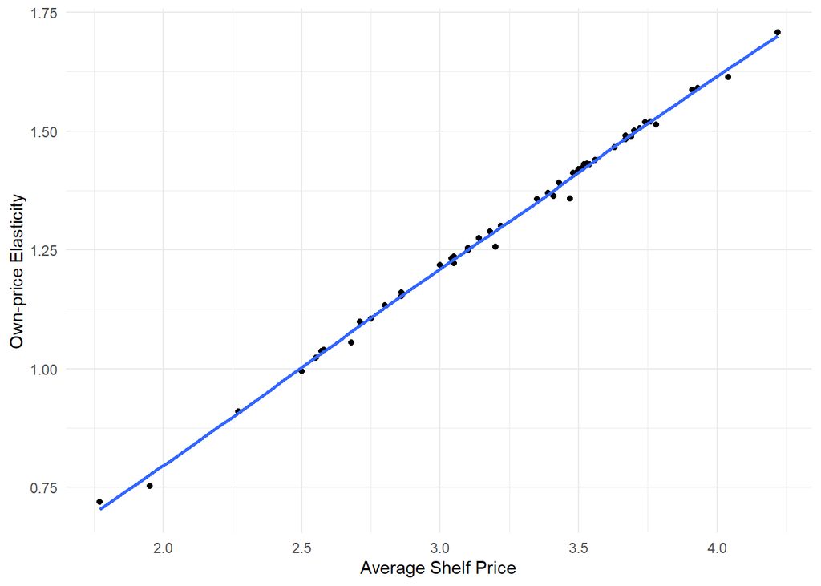

```r
library(ggplot2)

# Create a data frame with the own price elasticities and prices
elasticity_df <- data.frame(
  Avg_Shelf_Price = cerealdata$`Avg Shelf Price`,
  Own_Price_Elasticity = own_price_elasticity
)

# Plot own price elasticities against prices using ggplot2
plot_elas_1 <- ggplot(elasticity_df, aes(x = Avg_Shelf_Price, y = Own_Price_Elasticity)) +
  geom_point() +
  geom_smooth(method = "loess", se = FALSE) +
  labs(x = "Average Shelf Price", y = "Own-price Elasticity") +
  theme_minimal()

ggsave("Own price elasticities against price.jpeg", plot = plot_elas_1, dpi = 900 )
print(plot_elas_1)
```

#Plot markups against prices

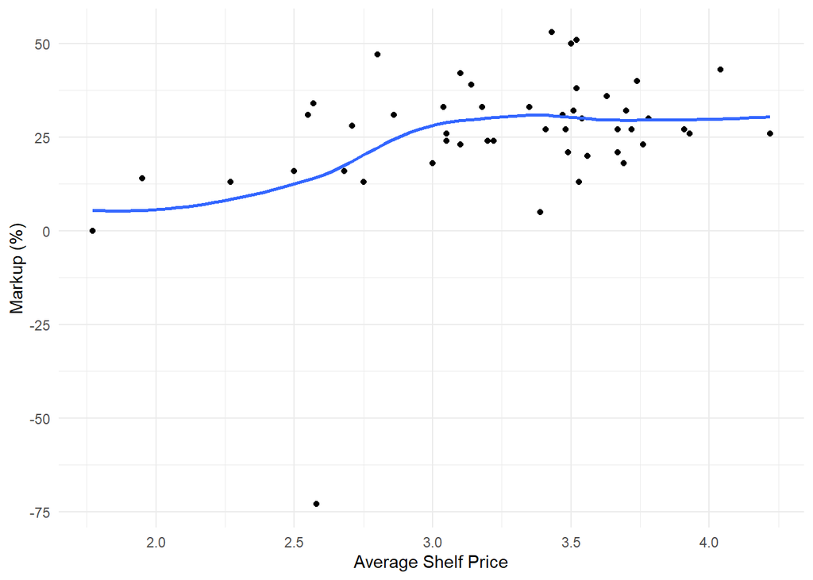

```r
library(ggplot2)
library(dplyr)

# Calculate markup as a percentage
cerealdata <- cerealdata %>%
  mutate(markup_percentage = discount_coupon * 100)

# Plot markups against prices using ggplot2
plot_elas_2 <- ggplot(cerealdata, aes(x = `Avg Shelf Price`, y = markup_percentage)) +
  geom_point() +
  geom_smooth(method = "loess", se = FALSE) +
  labs(x = "Average Shelf Price", y = "Markup (%)") +
  theme_minimal()

ggsave("Markups against prices.jpeg", plot = plot_elas_2, dpi = 900)
print(plot_elas_2)
```

#matrix 50X 50

```r
# Extract coefficients
coefficients <- coef(iv2a_6)

# Get the number of products
num_products <- nrow(cerealdata)

# Initialize an empty matrix to store the elasticities
elasticity_matrix <- matrix(0, nrow = num_products, ncol = num_products)

# Calculate own-price elasticity (j = k) and cross-price elasticity (j ≠ k)
for (j in 1:num_products) {
  for (k in 1:num_products) {
    if (j == k) {
      # Calculate own-price elasticity
      elasticity_matrix[j, k] <- -coefficients["fit_`Avg Shelf Price`"] * cerealdata$`Avg Shelf Price`[j] * (1 - (cerealdata$`Mkt Share`[j]/100))
    } else {
      # Calculate cross-price elasticity
      elasticity_matrix[j, k] <- coefficients["fit_`Avg Shelf Price`"] * cerealdata$`Avg Shelf Price`[j] * (cerealdata$`Mkt Share`[k]/100)
    }
  }
}

write.csv(elasticity_matrix, file = "elasticity_matrix.csv", row.names = FALSE)

# Print the elasticity matrix
print(elasticity_matrix)
```

[output not shown]

[output cut: 495 more lines]

```r
# Load the xtable package
library(xtable)

# Extract coefficients
coefficients <- coef(iv2a_6)

# Get the number of products
num_products <- nrow(cerealdata)

# Initialize an empty matrix to store the elasticities
elasticity_matrix <- matrix(0, nrow = num_products, ncol = num_products)

# Calculate own-price elasticity (j = k) and cross-price elasticity (j ≠ k)
for (j in 1:num_products) {
  for (k in 1:num_products) {
    if (j == k) {
      # Calculate own-price elasticity
      elasticity_matrix[j, k] <- -coefficients["fit_`Avg Shelf Price`"] * cerealdata$`Avg Shelf Price`[j] * (1 - (cerealdata$`Mkt Share`[j]/100))
    } else {
      # Calculate cross-price elasticity
      elasticity_matrix[j, k] <- coefficients["fit_`Avg Shelf Price`"] * cerealdata$`Avg Shelf Price`[j] * (cerealdata$`Mkt Share`[k]/100)
    }
  }
}

# Create a LaTeX table
latex_table <- xtable(elasticity_matrix, caption = "Elasticity Matrix")

# Write the LaTeX table to a file
print(latex_table, file = "elasticity_matrix.tex")
```

```r
# Extract coefficients
coefficients <- coef(iv2a_6)

# Get the number of products
num_products <- nrow(cerealdata)

# Initialize an empty matrix to store the elasticities
elasticity_matrix <- matrix(0, nrow = num_products, ncol = num_products)

# Calculate own-price elasticity (j = k) and cross-price elasticity (j ≠ k)
for (j in 1:num_products) {
  for (k in 1:num_products) {
    if (j == k) {
      # Calculate own-price elasticity
      elasticity_matrix[j, k] <- -coefficients["fit_`Avg Shelf Price`"] * cerealdata$`Avg Shelf Price`[j] * (1 - (cerealdata$`Mkt Share`[j]/100))
    } else {
      # Calculate cross-price elasticity
      elasticity_matrix[j, k] <- coefficients["fit_`Avg Shelf Price`"] * cerealdata$`Avg Shelf Price`[j] * (cerealdata$`Mkt Share`[k]/100)
    }
  }
}

# Convert the matrix to a data frame for xtable
df_elasticity <- as.data.frame(elasticity_matrix)

# Creating LaTeX code for the table
latex_table <- xtable(df_elasticity, caption = "Elasticity Matrix", label = "tab:elasticity_matrix")

# Printing the LaTeX code for the table
print(latex_table, type = "latex", include.rownames = FALSE,
      sanitize.text.function = function(x){x},
      floating = FALSE,
      hline.after = c(-1, 0, nrow(df_elasticity)),
      booktabs = TRUE)
```

[output not shown]

[output cut: 42 more lines]

```r
# Saving the LaTeX code to a file
writeLines(capture.output(print(latex_table, type = "latex", include.rownames = FALSE,
                                sanitize.text.function = function(x){x},
                                floating = FALSE,
                                hline.after = c(-1, 0, nrow(df_elasticity)),
                                booktabs = TRUE)),
           "elasticity_matrix.tex")
```